# Capstone Project - The Battle of Neighborhoods (Weeks 1-2)

### Parisian restaurants

#### A description of the problem and a discussion of the background.

The last 2 lessons of the IBM Applied Data Science Capstone course allow us to use machine learning techniques on real-world projects. During this course we've learned segmentation and clustering methods. For this we've used Toronto, Ontario, Canada and New York city, the USA datasets. This data included 2 data sources: neighborhoods and Foursquare API data with its users reviews. So now, I'll try to implement received knowledge using Paris, France data about its Arrondissements (districts) and corresponding Quarters (neighborhoods).

The main goal of this project is to make a recommendation where in a city of my choice I would suggest to open a restaurant. I was interested in Paris, France as a city of my choice. The task for this project says about Paris - "very diverse and is the financial capital of country". In France there's a lot of tourist places, but with Paris it is very difficult to compete with any other city in France, and probably there will be enough data on restaurants and cafes.

#### A description of the data and how it will be used to solve the problem.

The following data (20 boroughs and 80 neighborhoods) was used to determine the best place to open a restaurant in Paris:

   https://www.data.gouv.fr/en/datasets/arrondissements-1/#_
1. Quarters data (Wikipedia). This data includes quarter names and their areas, as well as corresponding arrondissements. To get this data BeautifulSoup module was used.

   https://fr.wikipedia.org/wiki/Liste_des_quartiers_administratifs_de_Paris

**Methodology.**

There were made 3 steps to achieve a goal of this project:

Part 1: Load and prepare data (data collection, cleaning, joining all datasets together).

Part 2: Get the latitude and the longitude coordinates of each neighborhood.

Part 3: Exploring and clustering the neighborhoods in Paris (visualization the resulting clusters). Clustering (K-Means) was used to analyze neighborhood data.

```python
!jupyter trust assignment2.ipynb
```

```
Signing notebook: assignment2.ipynb
```

# Part 1: *Load and prepare data*

**Import libraries.**

```python
import numpy as np # library to handle data in a vectorized manner

import pandas as pd # library for data analsysis
import copy
import os
pd.set_option('display.max_columns', None)
pd.set_option('display.max_rows', None)

import json # library to handle JSON files
from pandas.io.json import json_normalize # tranform JSON file into a pandas dataframe

import requests # library to handle requests
from bs4 import BeautifulSoup

import geocoder # convert an address into latitude and longitude values
from geopy.geocoders import Nominatim # convert an address into latitude and longitude values

# Matplotlib and associated plotting modules
import matplotlib.cm as cm
import matplotlib.colors as colors
import matplotlib.pyplot as plt

# import k-means from clustering stage
from sklearn.cluster import KMeans

import folium # map rendering library

print('Libraries imported.')
```

```
Libraries imported.
```

**Arrondissements of Paris - municipal boroughs.**

```python
# Construct file name

file_dir = 'C:\\Sasha\\udacity\\coursera\\Applied Data Science Specialization\\4 Applied Data Science Capstone\\4 The Battle of Neighborhoods'
file_name = 'arrondissements.csv'
result_path = os.path.join(file_dir, file_name)
```

```python
# Load data

boroughs = pd.read_csv(result_path, sep=';')
boroughs.head(2)
```

|  | Identifiant séquentiel de l’arrondissement | Numéro d’arrondissement | Numéro d’arrondissement INSEE | Nom de l’arrondissement | Nom officiel de l’arrondissement | N_SQ_CO | Surface | Périmètre | Geometry X Y | Geometry |
| --- | --- | --- | --- | --- | --- | --- | --- | --- | --- | --- |
| 0 | 750000003 | 3 | 75103 | 3ème Ardt | Temple | 750001537 | 1.170883e+06 | 4519.263648 | 48.86287238,2.3600009859 | {"type": "Polygon", "coordinates": [[[2.363828... |
| 1 | 750000007 | 7 | 75107 | 7ème Ardt | Palais-Bourbon | 750001537 | 4.090057e+06 | 8099.424883 | 48.8561744288,2.31218769148 | {"type": "Polygon", "coordinates": [[[2.320902... |

```python
# Sort data, delete usefull columns, set index, and rename index and columns

boroughs.sort_values('Numéro d’arrondissement INSEE', inplace=True)
boroughs.reset_index(drop=True, inplace=True)

list_to_drop = ['Identifiant séquentiel de l’arrondissement', 'N_SQ_CO', 'Geometry X Y', 'Geometry']
boroughs.drop(list_to_drop, axis=1, inplace=True)

boroughs.set_index('Numéro d’arrondissement', inplace=True)

boroughs.index.name = 'Identifier'
boroughs.columns = ['PostalCode', 'Arrondissement', 'Borough', 'Arrondissement\'s Area', 'Arrondissement\'s Perimeter']
```

```python
# Edit PostalCode column

boroughs.PostalCode = boroughs.PostalCode - 100
```

```python
# Look at preliminary result

boroughs
```

| Identifier | PostalCode | Arrondissement | Borough | Arrondissement's Area | Arrondissement's Perimeter |
| --- | --- | --- | --- | --- | --- |
| 1 | 75001 | 1er Ardt | Louvre | 1.824613e+06 | 6054.936862 |
| 2 | 75002 | 2ème Ardt | Bourse | 9.911537e+05 | 4554.104360 |
| 3 | 75003 | 3ème Ardt | Temple | 1.170883e+06 | 4519.263648 |
| 4 | 75004 | 4ème Ardt | Hôtel-de-Ville | 1.600586e+06 | 5420.908434 |
| 5 | 75005 | 5ème Ardt | Panthéon | 2.539375e+06 | 6239.195396 |
| 6 | 75006 | 6ème Ardt | Luxembourg | 2.153096e+06 | 6483.686786 |
| 7 | 75007 | 7ème Ardt | Palais-Bourbon | 4.090057e+06 | 8099.424883 |
| 8 | 75008 | 8ème Ardt | Élysée | 3.880036e+06 | 7880.533268 |
| 9 | 75009 | 9ème Ardt | Opéra | 2.178303e+06 | 6471.588290 |
| 10 | 75010 | 10ème Ardt | Entrepôt | 2.891739e+06 | 6739.375055 |
| 11 | 75011 | 11ème Ardt | Popincourt | 3.665442e+06 | 8282.011886 |
| 12 | 75012 | 12ème Ardt | Reuilly | 1.631478e+07 | 24089.666298 |
| 13 | 75013 | 13ème Ardt | Gobelins | 7.149311e+06 | 11546.546526 |
| 14 | 75014 | 14ème Ardt | Observatoire | 5.614877e+06 | 10317.483310 |
| 15 | 75015 | 15ème Ardt | Vaugirard | 8.494994e+06 | 13678.798315 |
| 16 | 75016 | 16ème Ardt | Passy | 1.637254e+07 | 17416.109657 |
| 17 | 75017 | 17ème Ardt | Batignolles-Monceau | 5.668835e+06 | 10775.579516 |
| 18 | 75018 | 18ème Ardt | Buttes-Montmartre | 5.996051e+06 | 9916.464176 |
| 19 | 75019 | 19ème Ardt | Buttes-Chaumont | 6.792651e+06 | 11253.182479 |
| 20 | 75020 | 20ème Ardt | Ménilmontant | 5.983446e+06 | 10704.940486 |

**Quartiers (Quarters) of Paris - municipal neighborhoods.**

```python
neighborhood_num, neighborhood, area = [], [], []
```

```python
adress = 'https://fr.wikipedia.org/wiki/Liste_des_quartiers_administratifs_de_Paris'
page = requests.get(adress)
soup = BeautifulSoup(page.text, 'html.parser')

tags_table = soup.find('table', {'class': 'wikitable sortable'}) # find table with postal codes
table = tags_table.find_all('tr') # Links to cities
```

```python
for line in table:
    rows = line.find_all('td', style=None)
    if rows:
        if len(rows) == 7:
            cnt = 0
            for word in rows:
                if 'arrondissementdit' in word.text:
                    cnt = 1
                elif cnt == 1:
                    neighborhood_num.append(word.text)
                    cnt += 1
                elif cnt == 2:
                    neighborhood.append(word.text)
                    cnt += 1
                elif ',' in word.text:
                    area.append(word.text.replace(',', '.'))
                    cnt += 1
        elif len(rows) == 5:
            cnt = 0
            for word in rows:
                if cnt == 0:
                    neighborhood_num.append(word.text)
                    cnt += 1
                elif cnt == 1:
                    neighborhood.append(word.text)
                    cnt += 1
                elif ',' in word.text:
                    area.append(word.text.replace(',', '.'))
                    cnt += 1
```

```python
# Create list of boroughs

borough = []
for i in range(1,21):
    borough += [i]*4
print('Len borough is', len(borough))
borough[:20]
```

```
Len borough is 80
```

```
[1, 1, 1, 1, 2, 2, 2, 2, 3, 3, 3, 3, 4, 4, 4, 4, 5, 5, 5, 5]
```

```python
# Check length of 4 lists (borough, neighborhood, neighborhood_num, and area)

len(borough), len(neighborhood), len(neighborhood_num), len(area)
```

```
(80, 80, 80, 80)
```

```python
# Instantiate the dataframe

neighborhoods = pd.DataFrame(zip(*(borough, neighborhood, neighborhood_num, area)),
                             columns=['Borough', 'Neighborhood', 'Neighborhood\'s number', 'Neighborhood\'s Area'])

# Set index
neighborhoods.set_index('Borough', inplace=True)
neighborhoods.index.name = 'Identifier'

neighborhoods.head()
```

| Identifier | Neighborhood | Neighborhood's number | Neighborhood's Area |
| --- | --- | --- | --- |
| 1 | Saint-Germain-l'Auxerrois | 1er | 86.9 |
| 1 | Halles | 2e | 41.2 |
| 1 | Palais-Royal | 3e | 27.4 |
| 1 | Place-Vendôme | 4e | 26.9 |
| 2 | Gaillon | 5e | 18.8 |

**Join boroughs and neighborhoods DataFrames.**

The dataframe will consist of six columns: PostalCode, Borough, Arrondissement's Area, Arrondissement's Perimeter , Neighborhood, and Neighborhood's Area.

```python
# Join  the dataframe

df = boroughs.join(neighborhoods)
df.reset_index(drop=True, inplace=True)
df.head()
```

|  | PostalCode | Arrondissement | Borough | Arrondissement's Area | Arrondissement's Perimeter | Neighborhood | Neighborhood's number | Neighborhood's Area |
| --- | --- | --- | --- | --- | --- | --- | --- | --- |
| 0 | 75001 | 1er Ardt | Louvre | 1.824613e+06 | 6054.936862 | Saint-Germain-l'Auxerrois | 1er | 86.9 |
| 1 | 75001 | 1er Ardt | Louvre | 1.824613e+06 | 6054.936862 | Halles | 2e | 41.2 |
| 2 | 75001 | 1er Ardt | Louvre | 1.824613e+06 | 6054.936862 | Palais-Royal | 3e | 27.4 |
| 3 | 75001 | 1er Ardt | Louvre | 1.824613e+06 | 6054.936862 | Place-Vendôme | 4e | 26.9 |
| 4 | 75002 | 2ème Ardt | Bourse | 9.911537e+05 | 4554.104360 | Gaillon | 5e | 18.8 |

```python
# Delete usefull columns

df.drop(['Arrondissement', 'Neighborhood\'s number'], axis=1, inplace=True)
```

Print the number of rows & columns in a dataframe and look at 1st 5 rows.

```python
print('Shape:', df.shape)
df.head()
```

```
Shape: (80, 6)
```

|  | PostalCode | Borough | Arrondissement's Area | Arrondissement's Perimeter | Neighborhood | Neighborhood's Area |
| --- | --- | --- | --- | --- | --- | --- |
| 0 | 75001 | Louvre | 1.824613e+06 | 6054.936862 | Saint-Germain-l'Auxerrois | 86.9 |
| 1 | 75001 | Louvre | 1.824613e+06 | 6054.936862 | Halles | 41.2 |
| 2 | 75001 | Louvre | 1.824613e+06 | 6054.936862 | Palais-Royal | 27.4 |
| 3 | 75001 | Louvre | 1.824613e+06 | 6054.936862 | Place-Vendôme | 26.9 |
| 4 | 75002 | Bourse | 9.911537e+05 | 4554.104360 | Gaillon | 18.8 |

# Part 2: *Get the latitude and the longitude coordinates of each neighborhood*

```python
def get_latlon(neighborhood, postal_code):

    # initialize your variable to None
    lat_lng_coords = None

    # loop until you get the coordinates
    while(lat_lng_coords is None):
        g = geocoder.arcgis('{}, {}, Paris, FR'.format(neighborhood, postal_code))
        lat_lng_coords = g.latlng

    latitude = lat_lng_coords[0]
    longitude = lat_lng_coords[1]

    return latitude, longitude
```

```python
# Apply function

coordinates = []
latitude, longitude = [], []

for idx,row in df[['Neighborhood', 'PostalCode']].iterrows():
    neighbor, code = row['Neighborhood'], row['PostalCode']
    coordinates = get_latlon(neighbor, code)
    latitude.append(coordinates[0])
    longitude.append(coordinates[1])
```

```python
# Check the results

latitude[:5], longitude[:5]
```

```
([48.86140804265944,
  48.86218743953672,
  48.864708042972204,
  48.86778000000004,
  48.869020000000035],
 [2.3331228017315646,
  2.345242624547943,
  2.336495988403402,
  2.3301100000000474,
  2.3344500111085558])
```

```python
df['Latitude'] = latitude
df['Longitude'] = longitude
```

```python
df.head()
```

|  | PostalCode | Borough | Arrondissement's Area | Arrondissement's Perimeter | Neighborhood | Neighborhood's Area | Latitude | Longitude |
| --- | --- | --- | --- | --- | --- | --- | --- | --- |
| 0 | 75001 | Louvre | 1.824613e+06 | 6054.936862 | Saint-Germain-l'Auxerrois | 86.9 | 48.861408 | 2.333123 |
| 1 | 75001 | Louvre | 1.824613e+06 | 6054.936862 | Halles | 41.2 | 48.862187 | 2.345243 |
| 2 | 75001 | Louvre | 1.824613e+06 | 6054.936862 | Palais-Royal | 27.4 | 48.864708 | 2.336496 |
| 3 | 75001 | Louvre | 1.824613e+06 | 6054.936862 | Place-Vendôme | 26.9 | 48.867780 | 2.330110 |
| 4 | 75002 | Bourse | 9.911537e+05 | 4554.104360 | Gaillon | 18.8 | 48.869020 | 2.334450 |

# Part 3: *Exploring and clustering the neighborhoods in Paris*

Examine the resulting dataframe.

```python
neighborhoods = df.copy()

print('The dataframe has {} boroughs and {} neighborhoods.'.format(
        len(neighborhoods['Borough'].unique()),
        neighborhoods.shape[0]
    )
)

neighborhoods.head()
```

```
The dataframe has 20 boroughs and 80 neighborhoods.
```

|  | PostalCode | Borough | Arrondissement's Area | Arrondissement's Perimeter | Neighborhood | Neighborhood's Area | Latitude | Longitude |
| --- | --- | --- | --- | --- | --- | --- | --- | --- |
| 0 | 75001 | Louvre | 1.824613e+06 | 6054.936862 | Saint-Germain-l'Auxerrois | 86.9 | 48.861408 | 2.333123 |
| 1 | 75001 | Louvre | 1.824613e+06 | 6054.936862 | Halles | 41.2 | 48.862187 | 2.345243 |
| 2 | 75001 | Louvre | 1.824613e+06 | 6054.936862 | Palais-Royal | 27.4 | 48.864708 | 2.336496 |
| 3 | 75001 | Louvre | 1.824613e+06 | 6054.936862 | Place-Vendôme | 26.9 | 48.867780 | 2.330110 |
| 4 | 75002 | Bourse | 9.911537e+05 | 4554.104360 | Gaillon | 18.8 | 48.869020 | 2.334450 |

Use geopy library to get the latitude and longitude values of Palais-Royal, Paris, FR. In order to define an instance of the geocoder, a user_agent is defined. The name of an agent is ny_explorer, as shown below.

```python
address = 'Palais-Royal, Paris, FR'

geolocator = Nominatim(user_agent="ny_explorer")
location = geolocator.geocode(address)
latitude = location.latitude
longitude = location.longitude
print('The geograpical coordinate of Palais-Royal, Paris are {}, {}.'.format(latitude, longitude))
```

```
The geograpical coordinate of Palais-Royal, Paris are 48.863584700000004, 2.3362042200938715.
```

Create a map of Paris with neighborhoods superimposed on top.

```python
# create map of Paris using latitude and longitude values
map_paris = folium.Map(location=[latitude, longitude], zoom_start=12)

# add markers to map
for lat, lng, borough, neighborhood in zip(neighborhoods['Latitude'], neighborhoods['Longitude'], neighborhoods['Borough'], neighborhoods['Neighborhood']):
    label = '{}, {}'.format(neighborhood, borough)
    label = folium.Popup(label, parse_html=True)
    folium.CircleMarker(
        [lat, lng],
        radius=5,
        popup=label,
        color='blue',
        fill=True,
        fill_color='#3186cc',
        fill_opacity=0.7,
        parse_html=False).add_to(map_paris)

map_paris
```

Make this Notebook Trusted to load map: File -> Trust Notebook

[interactive chart not shown]

**Foursquare API.**

Define Foursquare Credentials and Version

```python
CLIENT_ID = 'D5HCS5AUYRJUG2YL1OJFLXO5V3VJASRMXAXGSF1Y111GXKSP' # Foursquare ID
CLIENT_SECRET = 'CBS4MJPQFHVM41IL0E5LEJ4QRARFWFPPYBOVSYZ4F5GKQCMY' # Foursquare Secret
VERSION = '20200620' # Foursquare API version

print('Your credentails:')
print('CLIENT_ID: ' + CLIENT_ID)
print('CLIENT_SECRET:' + CLIENT_SECRET)
```

```
Your credentails:
CLIENT_ID: D5HCS5AUYRJUG2YL1OJFLXO5V3VJASRMXAXGSF1Y111GXKSP
CLIENT_SECRET:CBS4MJPQFHVM41IL0E5LEJ4QRARFWFPPYBOVSYZ4F5GKQCMY
```

Let's explore the first neighborhood in our dataframe. Get the neighborhood's name.

```python
neighborhoods.loc[0, 'Neighborhood']
```

```
"Saint-Germain-l'Auxerrois"
```

Get the neighborhood's latitude and longitude values.

```python
neighborhood_latitude = neighborhoods.loc[0, 'Latitude'] # neighborhood latitude value
neighborhood_longitude = neighborhoods.loc[0, 'Longitude'] # neighborhood longitude value

neighborhood_name = neighborhoods.loc[0, 'Neighborhood'] # neighborhood name

print('Latitude and longitude values of {} are {}, {}.'.format(neighborhood_name,
                                                               neighborhood_latitude,
                                                               neighborhood_longitude))
```

```
Latitude and longitude values of Saint-Germain-l'Auxerrois are 48.86140804265944, 2.3331228017315646.
```

```python
LIMIT = 100 # limit of number of venues returned by Foursquare API

radius = 500 # define radius

url = 'https://api.foursquare.com/v2/venues/explore?&client_id={}&client_secret={}&v={}&ll={},{}&radius={}&limit={}'.format(
    CLIENT_ID,
    CLIENT_SECRET,
    VERSION,
    neighborhood_latitude,
    neighborhood_longitude,
    radius,
    LIMIT)
url # display URL
```

```
'https://api.foursquare.com/v2/venues/explore?&client_id=D5HCS5AUYRJUG2YL1OJFLXO5V3VJASRMXAXGSF1Y111GXKSP&client_secret=CBS4MJPQFHVM41IL0E5LEJ4QRARFWFPPYBOVSYZ4F5GKQCMY&v=20200620&ll=48.86140804265944,2.3331228017315646&radius=500&limit=100'
```

Send the GET request and examine the resutls

```python
results = requests.get(url).json()
results
```

[output not shown]

[output cut: 1305 more lines]

[output not shown]

Clean the json and structure it into a pandas dataframe.

```python
# function that extracts the category of the venue
def get_category_type(row):
    try:
        categories_list = row['categories']
    except:
        categories_list = row['venue.categories']

    if len(categories_list) == 0:
        return None
    else:
        return categories_list[0]['name']
```

```python
venues = results['response']['groups'][0]['items']

nearby_venues = json_normalize(venues) # flatten JSON

# filter columns
filtered_columns = ['venue.name', 'venue.categories', 'venue.location.lat', 'venue.location.lng']
nearby_venues =nearby_venues.loc[:, filtered_columns]

# filter the category for each row
nearby_venues['venue.categories'] = nearby_venues.apply(get_category_type, axis=1)

# clean columns
nearby_venues.columns = [col.split(".")[-1] for col in nearby_venues.columns]

nearby_venues.head()
```

|  | name | categories | lat | lng |
| --- | --- | --- | --- | --- |
| 0 | Vestige de la Forteresse du Louvre | Historic Site | 48.861577 | 2.333508 |
| 1 | Cour Napoléon | Plaza | 48.861172 | 2.335088 |
| 2 | Musée des Arts Décoratifs | Art Museum | 48.863077 | 2.333393 |
| 3 | Pavillon des Sessions – Arts d'Afrique, d'Asie... | Art Museum | 48.860724 | 2.332121 |
| 4 | LouLou | Italian Restaurant | 48.862804 | 2.333500 |

```python
print('{} venues were returned by Foursquare.'.format(nearby_venues.shape[0]))
```

```
47 venues were returned by Foursquare.
```

**Explore Neighborhoods in Paris.**

```python
def getNearbyVenues(names, latitudes, longitudes, radius=500):

    venues_list=[]
    for name, lat, lng in zip(names, latitudes, longitudes):
        print(name)

        # create the API request URL
        url = 'https://api.foursquare.com/v2/venues/explore?&client_id={}&client_secret={}&v={}&ll={},{}&radius={}&limit={}'.format(
            CLIENT_ID,
            CLIENT_SECRET,
            VERSION,
            lat,
            lng,
            radius,
            LIMIT)

        # make the GET request
        results = requests.get(url).json()["response"]['groups'][0]['items']

        # return only relevant information for each nearby venue
        venues_list.append([(
            name,
            lat,
            lng,
            v['venue']['name'],
            v['venue']['location']['lat'],
            v['venue']['location']['lng'],
            v['venue']['categories'][0]['name']) for v in results])

    nearby_venues = pd.DataFrame([item for venue_list in venues_list for item in venue_list])
    nearby_venues.columns = ['Neighborhood',
                  'Neighborhood Latitude',
                  'Neighborhood Longitude',
                  'Venue',
                  'Venue Latitude',
                  'Venue Longitude',
                  'Venue Category']

    return(nearby_venues)
```

Run the above function on each neighborhood and create a new dataframe called paris_venues.

```python
paris_venues = getNearbyVenues(names=neighborhoods['Neighborhood'],
                                   latitudes=neighborhoods['Latitude'],
                                   longitudes=neighborhoods['Longitude']
                                  )
```

```
Saint-Germain-l'Auxerrois
Halles
Palais-Royal
Place-Vendôme
Gaillon
Vivienne
Mail
Bonne-Nouvelle
Arts-et-Métiers
Enfants-Rouges
Archives
Sainte-Avoye
Saint-Merri
Saint-Gervais
Arsenal
Notre-Dame
Saint-Victor
Jardin-des-Plantes
Val-de-Grâce
Sorbonne
Monnaie
Odéon
Notre-Dame-des-Champs
Saint-Germain-des-Prés
Saint-Thomas-d'Aquin
Invalides
École-Militaire
Gros-Caillou
Champs-Élysées
Faubourg-du-Roule
Madeleine
Europe
Saint-Georges
Chaussée-d'Antin
Faubourg-Montmartre
Rochechouart
Saint-Vincent-de-Paul
Porte-Saint-Denis
Porte-Saint-Martin
Hôpital-Saint-Louis
```

[output cut: 25 more lines]

```
Plaine-de-Monceaux
Batignolles
Épinettes
Grandes-Carrières
Clignancourt
Goutte-d'Or
Chapelle
Villette
Pont-de-Flandre
Amérique
Combat
Belleville
Saint-Fargeau
Père-Lachaise
Charonne
```

Check the size of the resulting dataframe.

```python
print(paris_venues.shape)
paris_venues.head()
```

```
(5309, 7)
```

|  | Neighborhood | Neighborhood Latitude | Neighborhood Longitude | Venue | Venue Latitude | Venue Longitude | Venue Category |
| --- | --- | --- | --- | --- | --- | --- | --- |
| 0 | Saint-Germain-l'Auxerrois | 48.861408 | 2.333123 | Vestige de la Forteresse du Louvre | 48.861577 | 2.333508 | Historic Site |
| 1 | Saint-Germain-l'Auxerrois | 48.861408 | 2.333123 | Cour Napoléon | 48.861172 | 2.335088 | Plaza |
| 2 | Saint-Germain-l'Auxerrois | 48.861408 | 2.333123 | Musée des Arts Décoratifs | 48.863077 | 2.333393 | Art Museum |
| 3 | Saint-Germain-l'Auxerrois | 48.861408 | 2.333123 | Pavillon des Sessions – Arts d'Afrique, d'Asie... | 48.860724 | 2.332121 | Art Museum |
| 4 | Saint-Germain-l'Auxerrois | 48.861408 | 2.333123 | LouLou | 48.862804 | 2.333500 | Italian Restaurant |

Check how many venues were returned for each neighborhood.

```python
paris_venues.groupby('Neighborhood').count()
```

| Neighborhood | Neighborhood Latitude | Neighborhood Longitude | Venue | Venue Latitude | Venue Longitude | Venue Category |
| --- | --- | --- | --- | --- | --- | --- |
| Amérique | 37 | 37 | 37 | 37 | 37 | 37 |
| Archives | 94 | 94 | 94 | 94 | 94 | 94 |
| Arsenal | 71 | 71 | 71 | 71 | 71 | 71 |
| Arts-et-Métiers | 13 | 13 | 13 | 13 | 13 | 13 |
| Auteuil | 41 | 41 | 41 | 41 | 41 | 41 |
| Batignolles | 58 | 58 | 58 | 58 | 58 | 58 |
| Bel-Air | 30 | 30 | 30 | 30 | 30 | 30 |
| Belleville | 45 | 45 | 45 | 45 | 45 | 45 |
| Bercy | 47 | 47 | 47 | 47 | 47 | 47 |
| Bonne-Nouvelle | 83 | 83 | 83 | 83 | 83 | 83 |
| Chaillot | 100 | 100 | 100 | 100 | 100 | 100 |
| Champs-Élysées | 90 | 90 | 90 | 90 | 90 | 90 |
| Chapelle | 49 | 49 | 49 | 49 | 49 | 49 |
| Charonne | 56 | 56 | 56 | 56 | 56 | 56 |
| Chaussée-d'Antin | 83 | 83 | 83 | 83 | 83 | 83 |
| Clignancourt | 18 | 18 | 18 | 18 | 18 | 18 |
| Combat | 31 | 31 | 31 | 31 | 31 | 31 |
| Croulebarbe | 52 | 52 | 52 | 52 | 52 | 52 |
| Enfants-Rouges | 78 | 78 | 78 | 78 | 78 | 78 |
| Europe | 35 | 35 | 35 | 35 | 35 | 35 |
| Faubourg-Montmartre | 87 | 87 | 87 | 87 | 87 | 87 |
| Faubourg-du-Roule | 100 | 100 | 100 | 100 | 100 | 100 |
| Folie-Méricourt | 100 | 100 | 100 | 100 | 100 | 100 |
| Gaillon | 100 | 100 | 100 | 100 | 100 | 100 |
| Gare | 50 | 50 | 50 | 50 | 50 | 50 |
| Goutte-d'Or | 28 | 28 | 28 | 28 | 28 | 28 |
| Grandes-Carrières | 56 | 56 | 56 | 56 | 56 | 56 |
| Grenelle | 74 | 74 | 74 | 74 | 74 | 74 |
| Gros-Caillou | 100 | 100 | 100 | 100 | 100 | 100 |
| Halles | 61 | 61 | 61 | 61 | 61 | 61 |
| Hôpital-Saint-Louis | 76 | 76 | 76 | 76 | 76 | 76 |
| Invalides | 54 | 54 | 54 | 54 | 54 | 54 |
| Jardin-des-Plantes | 60 | 60 | 60 | 60 | 60 | 60 |
| Javel | 76 | 76 | 76 | 76 | 76 | 76 |
| Madeleine | 100 | 100 | 100 | 100 | 100 | 100 |
| Mail | 100 | 100 | 100 | 100 | 100 | 100 |
| Maison-Blanche | 72 | 72 | 72 | 72 | 72 | 72 |
| Monnaie | 91 | 91 | 91 | 91 | 91 | 91 |
| Montparnasse | 82 | 82 | 82 | 82 | 82 | 82 |
| Muette | 37 | 37 | 37 | 37 | 37 | 37 |
| Necker | 45 | 45 | 45 | 45 | 45 | 45 |
| Notre-Dame | 65 | 65 | 65 | 65 | 65 | 65 |
| Notre-Dame-des-Champs | 47 | 47 | 47 | 47 | 47 | 47 |
| Odéon | 63 | 63 | 63 | 63 | 63 | 63 |
| Palais-Royal | 100 | 100 | 100 | 100 | 100 | 100 |
| Parc-de-Montsouris | 18 | 18 | 18 | 18 | 18 | 18 |
| Petit-Montrouge | 63 | 63 | 63 | 63 | 63 | 63 |
| Picpus | 35 | 35 | 35 | 35 | 35 | 35 |
| Place-Vendôme | 100 | 100 | 100 | 100 | 100 | 100 |
| Plaine-de-Monceaux | 51 | 51 | 51 | 51 | 51 | 51 |
| Plaisance | 59 | 59 | 59 | 59 | 59 | 59 |
| Pont-de-Flandre | 44 | 44 | 44 | 44 | 44 | 44 |
| Porte-Dauphine | 70 | 70 | 70 | 70 | 70 | 70 |
| Porte-Saint-Denis | 69 | 69 | 69 | 69 | 69 | 69 |
| Porte-Saint-Martin | 100 | 100 | 100 | 100 | 100 | 100 |
| Père-Lachaise | 18 | 18 | 18 | 18 | 18 | 18 |
| Quinze-Vingts | 71 | 71 | 71 | 71 | 71 | 71 |
| Rochechouart | 77 | 77 | 77 | 77 | 77 | 77 |
| Roquette | 100 | 100 | 100 | 100 | 100 | 100 |
| Saint-Ambroise | 66 | 66 | 66 | 66 | 66 | 66 |
| Saint-Fargeau | 18 | 18 | 18 | 18 | 18 | 18 |
| Saint-Georges | 100 | 100 | 100 | 100 | 100 | 100 |
| Saint-Germain-des-Prés | 100 | 100 | 100 | 100 | 100 | 100 |
| Saint-Germain-l'Auxerrois | 47 | 47 | 47 | 47 | 47 | 47 |
| Saint-Gervais | 100 | 100 | 100 | 100 | 100 | 100 |
| Saint-Lambert | 53 | 53 | 53 | 53 | 53 | 53 |
| Saint-Merri | 98 | 98 | 98 | 98 | 98 | 98 |
| Saint-Thomas-d'Aquin | 82 | 82 | 82 | 82 | 82 | 82 |
| Saint-Victor | 94 | 94 | 94 | 94 | 94 | 94 |
| Saint-Vincent-de-Paul | 83 | 83 | 83 | 83 | 83 | 83 |
| Sainte-Avoye | 69 | 69 | 69 | 69 | 69 | 69 |
| Sainte-Marguerite | 91 | 91 | 91 | 91 | 91 | 91 |
| Salpêtrière | 79 | 79 | 79 | 79 | 79 | 79 |
| Sorbonne | 100 | 100 | 100 | 100 | 100 | 100 |
| Ternes | 100 | 100 | 100 | 100 | 100 | 100 |
| Val-de-Grâce | 48 | 48 | 48 | 48 | 48 | 48 |
| Villette | 45 | 45 | 45 | 45 | 45 | 45 |
| Vivienne | 59 | 59 | 59 | 59 | 59 | 59 |
| École-Militaire | 31 | 31 | 31 | 31 | 31 | 31 |
| Épinettes | 36 | 36 | 36 | 36 | 36 | 36 |

Find out how many unique categories can be curated from all the returned venues.

```python
print('There are {} uniques categories.'.format(len(paris_venues['Venue Category'].unique())))
```

```
There are 288 uniques categories.
```

**Analyze Each Neighborhood.**

```python
# one hot encoding
paris_onehot = pd.get_dummies(paris_venues[['Venue Category']], prefix="", prefix_sep="")

# add neighborhood column back to dataframe
paris_onehot['Neighborhood'] = paris_venues['Neighborhood']

# move neighborhood column to the first column
fixed_columns = [paris_onehot.columns[-1]] + list(paris_onehot.columns[:-1])
paris_onehot = paris_onehot[fixed_columns]

paris_onehot.head()
```

|  | Neighborhood | Accessories Store | Afghan Restaurant | African Restaurant | Alsatian Restaurant | American Restaurant | Antique Shop | Argentinian Restaurant | Art Gallery | Art Museum | Arts & Crafts Store | Arts & Entertainment | Asian Restaurant | Athletics & Sports | Auvergne Restaurant | BBQ Joint | Bagel Shop | Bakery | Bar | Bed & Breakfast | Beer Bar | Beer Garden | Beer Store | Big Box Store | Bike Rental / Bike Share | Bistro | Boat or Ferry | Bookstore | Botanical Garden | … |
| --- | --- | --- | --- | --- | --- | --- | --- | --- | --- | --- | --- | --- | --- | --- | --- | --- | --- | --- | --- | --- | --- | --- | --- | --- | --- | --- | --- | --- | --- | --- |
| 0 | Saint-Germain-l'Auxerrois | 0 | 0 | 0 | 0 | 0 | 0 | 0 | 0 | 0 | 0 | 0 | 0 | 0 | 0 | 0 | 0 | 0 | 0 | 0 | 0 | 0 | 0 | 0 | 0 | 0 | 0 | 0 | 0 | … |
| 1 | Saint-Germain-l'Auxerrois | 0 | 0 | 0 | 0 | 0 | 0 | 0 | 0 | 0 | 0 | 0 | 0 | 0 | 0 | 0 | 0 | 0 | 0 | 0 | 0 | 0 | 0 | 0 | 0 | 0 | 0 | 0 | 0 | … |
| 2 | Saint-Germain-l'Auxerrois | 0 | 0 | 0 | 0 | 0 | 0 | 0 | 0 | 1 | 0 | 0 | 0 | 0 | 0 | 0 | 0 | 0 | 0 | 0 | 0 | 0 | 0 | 0 | 0 | 0 | 0 | 0 | 0 | … |
| 3 | Saint-Germain-l'Auxerrois | 0 | 0 | 0 | 0 | 0 | 0 | 0 | 0 | 1 | 0 | 0 | 0 | 0 | 0 | 0 | 0 | 0 | 0 | 0 | 0 | 0 | 0 | 0 | 0 | 0 | 0 | 0 | 0 | … |
| 4 | Saint-Germain-l'Auxerrois | 0 | 0 | 0 | 0 | 0 | 0 | 0 | 0 | 0 | 0 | 0 | 0 | 0 | 0 | 0 | 0 | 0 | 0 | 0 | 0 | 0 | 0 | 0 | 0 | 0 | 0 | 0 | 0 | … |

Examine the new dataframe size.

```python
paris_onehot.shape
```

```
(5309, 289)
```

Group rows by neighborhood and by taking the mean of the frequency of occurrence of each category.

```python
paris_grouped = paris_onehot.groupby('Neighborhood').mean().reset_index()
paris_grouped
```

|  | Neighborhood | Accessories Store | Afghan Restaurant | African Restaurant | Alsatian Restaurant | American Restaurant | Antique Shop | Argentinian Restaurant | Art Gallery | Art Museum | Arts & Crafts Store | Arts & Entertainment | Asian Restaurant | Athletics & Sports | Auvergne Restaurant | BBQ Joint | Bagel Shop | Bakery | Bar | Bed & Breakfast | Beer Bar | Beer Garden | Beer Store | Big Box Store | Bike Rental / Bike Share | Bistro | Boat or Ferry | Bookstore | Botanical Garden | … |
| --- | --- | --- | --- | --- | --- | --- | --- | --- | --- | --- | --- | --- | --- | --- | --- | --- | --- | --- | --- | --- | --- | --- | --- | --- | --- | --- | --- | --- | --- | --- |
| 0 | Amérique | 0.000000 | 0.000000 | 0.027027 | 0.000000 | 0.000000 | 0.000000 | 0.000000 | 0.000000 | 0.000000 | 0.000000 | 0.00 | 0.027027 | 0.000000 | 0.000000 | 0.000000 | 0.000000 | 0.081081 | 0.135135 | 0.000000 | 0.000000 | 0.000000 | 0.027027 | 0.000000 | 0.000000 | 0.027027 | 0.000000 | 0.000000 | 0.000000 | … |
| 1 | Archives | 0.000000 | 0.000000 | 0.000000 | 0.000000 | 0.000000 | 0.000000 | 0.010638 | 0.042553 | 0.010638 | 0.000000 | 0.00 | 0.010638 | 0.000000 | 0.000000 | 0.000000 | 0.000000 | 0.031915 | 0.010638 | 0.000000 | 0.000000 | 0.000000 | 0.000000 | 0.000000 | 0.000000 | 0.031915 | 0.000000 | 0.010638 | 0.000000 | … |
| 2 | Arsenal | 0.000000 | 0.000000 | 0.000000 | 0.000000 | 0.000000 | 0.000000 | 0.000000 | 0.000000 | 0.000000 | 0.000000 | 0.00 | 0.014085 | 0.000000 | 0.000000 | 0.000000 | 0.000000 | 0.000000 | 0.014085 | 0.000000 | 0.000000 | 0.000000 | 0.014085 | 0.000000 | 0.000000 | 0.000000 | 0.028169 | 0.000000 | 0.000000 | … |
| 3 | Arts-et-Métiers | 0.000000 | 0.000000 | 0.000000 | 0.000000 | 0.000000 | 0.000000 | 0.000000 | 0.000000 | 0.000000 | 0.000000 | 0.00 | 0.000000 | 0.000000 | 0.000000 | 0.076923 | 0.000000 | 0.000000 | 0.000000 | 0.000000 | 0.000000 | 0.000000 | 0.000000 | 0.000000 | 0.000000 | 0.000000 | 0.000000 | 0.000000 | 0.000000 | … |
| 4 | Auteuil | 0.000000 | 0.000000 | 0.000000 | 0.000000 | 0.000000 | 0.000000 | 0.000000 | 0.024390 | 0.000000 | 0.000000 | 0.00 | 0.000000 | 0.000000 | 0.000000 | 0.000000 | 0.000000 | 0.000000 | 0.000000 | 0.000000 | 0.000000 | 0.000000 | 0.000000 | 0.000000 | 0.000000 | 0.000000 | 0.000000 | 0.000000 | 0.024390 | … |
| 5 | Batignolles | 0.000000 | 0.000000 | 0.000000 | 0.000000 | 0.000000 | 0.000000 | 0.000000 | 0.000000 | 0.000000 | 0.000000 | 0.00 | 0.000000 | 0.000000 | 0.000000 | 0.017241 | 0.000000 | 0.017241 | 0.068966 | 0.000000 | 0.000000 | 0.000000 | 0.000000 | 0.000000 | 0.000000 | 0.034483 | 0.000000 | 0.000000 | 0.000000 | … |
| 6 | Bel-Air | 0.000000 | 0.000000 | 0.000000 | 0.000000 | 0.000000 | 0.000000 | 0.000000 | 0.033333 | 0.000000 | 0.000000 | 0.00 | 0.000000 | 0.000000 | 0.000000 | 0.000000 | 0.000000 | 0.033333 | 0.033333 | 0.000000 | 0.000000 | 0.000000 | 0.000000 | 0.000000 | 0.000000 | 0.000000 | 0.000000 | 0.000000 | 0.000000 | … |
| 7 | Belleville | 0.000000 | 0.000000 | 0.044444 | 0.000000 | 0.000000 | 0.000000 | 0.000000 | 0.000000 | 0.000000 | 0.000000 | 0.00 | 0.000000 | 0.000000 | 0.000000 | 0.000000 | 0.000000 | 0.022222 | 0.177778 | 0.000000 | 0.000000 | 0.000000 | 0.022222 | 0.000000 | 0.000000 | 0.044444 | 0.000000 | 0.022222 | 0.000000 | … |
| 8 | Bercy | 0.000000 | 0.000000 | 0.000000 | 0.000000 | 0.000000 | 0.000000 | 0.000000 | 0.000000 | 0.000000 | 0.021277 | 0.00 | 0.000000 | 0.000000 | 0.000000 | 0.000000 | 0.021277 | 0.042553 | 0.021277 | 0.000000 | 0.000000 | 0.000000 | 0.000000 | 0.021277 | 0.000000 | 0.000000 | 0.000000 | 0.000000 | 0.000000 | … |
| 9 | Bonne-Nouvelle | 0.000000 | 0.000000 | 0.000000 | 0.000000 | 0.000000 | 0.000000 | 0.000000 | 0.000000 | 0.000000 | 0.000000 | 0.00 | 0.000000 | 0.000000 | 0.000000 | 0.000000 | 0.000000 | 0.060241 | 0.060241 | 0.000000 | 0.012048 | 0.000000 | 0.000000 | 0.000000 | 0.000000 | 0.012048 | 0.000000 | 0.012048 | 0.000000 | … |
| 10 | Chaillot | 0.020000 | 0.000000 | 0.000000 | 0.000000 | 0.000000 | 0.000000 | 0.000000 | 0.010000 | 0.050000 | 0.000000 | 0.01 | 0.000000 | 0.000000 | 0.000000 | 0.000000 | 0.010000 | 0.010000 | 0.010000 | 0.000000 | 0.000000 | 0.000000 | 0.000000 | 0.000000 | 0.000000 | 0.010000 | 0.000000 | 0.010000 | 0.000000 | … |
| 11 | Champs-Élysées | 0.000000 | 0.000000 | 0.000000 | 0.000000 | 0.000000 | 0.000000 | 0.000000 | 0.033333 | 0.011111 | 0.000000 | 0.00 | 0.000000 | 0.000000 | 0.000000 | 0.000000 | 0.000000 | 0.000000 | 0.011111 | 0.000000 | 0.000000 | 0.000000 | 0.000000 | 0.000000 | 0.000000 | 0.000000 | 0.000000 | 0.000000 | 0.000000 | … |
| 12 | Chapelle | 0.000000 | 0.000000 | 0.000000 | 0.000000 | 0.000000 | 0.000000 | 0.000000 | 0.020408 | 0.000000 | 0.000000 | 0.00 | 0.000000 | 0.000000 | 0.000000 | 0.000000 | 0.000000 | 0.061224 | 0.020408 | 0.000000 | 0.020408 | 0.000000 | 0.000000 | 0.000000 | 0.000000 | 0.020408 | 0.000000 | 0.020408 | 0.000000 | … |
| 13 | Charonne | 0.000000 | 0.000000 | 0.000000 | 0.000000 | 0.000000 | 0.000000 | 0.000000 | 0.000000 | 0.000000 | 0.000000 | 0.00 | 0.000000 | 0.000000 | 0.000000 | 0.000000 | 0.017857 | 0.017857 | 0.107143 | 0.000000 | 0.000000 | 0.000000 | 0.000000 | 0.000000 | 0.000000 | 0.017857 | 0.000000 | 0.035714 | 0.000000 | … |
| 14 | Chaussée-d'Antin | 0.000000 | 0.000000 | 0.000000 | 0.000000 | 0.000000 | 0.000000 | 0.000000 | 0.000000 | 0.000000 | 0.000000 | 0.00 | 0.000000 | 0.000000 | 0.000000 | 0.000000 | 0.000000 | 0.000000 | 0.012048 | 0.000000 | 0.000000 | 0.000000 | 0.000000 | 0.000000 | 0.000000 | 0.048193 | 0.000000 | 0.000000 | 0.000000 | … |
| 15 | Clignancourt | 0.000000 | 0.000000 | 0.055556 | 0.000000 | 0.000000 | 0.000000 | 0.000000 | 0.000000 | 0.000000 | 0.000000 | 0.00 | 0.000000 | 0.000000 | 0.000000 | 0.000000 | 0.000000 | 0.000000 | 0.000000 | 0.000000 | 0.000000 | 0.055556 | 0.000000 | 0.000000 | 0.000000 | 0.055556 | 0.000000 | 0.000000 | 0.000000 | … |
| 16 | Combat | 0.000000 | 0.000000 | 0.000000 | 0.000000 | 0.000000 | 0.000000 | 0.000000 | 0.000000 | 0.000000 | 0.000000 | 0.00 | 0.000000 | 0.000000 | 0.000000 | 0.000000 | 0.000000 | 0.064516 | 0.064516 | 0.000000 | 0.000000 | 0.032258 | 0.000000 | 0.000000 | 0.000000 | 0.000000 | 0.000000 | 0.000000 | 0.000000 | … |
| 17 | Croulebarbe | 0.000000 | 0.000000 | 0.000000 | 0.000000 | 0.019231 | 0.000000 | 0.000000 | 0.000000 | 0.000000 | 0.000000 | 0.00 | 0.000000 | 0.000000 | 0.000000 | 0.000000 | 0.019231 | 0.038462 | 0.038462 | 0.000000 | 0.000000 | 0.000000 | 0.000000 | 0.000000 | 0.000000 | 0.000000 | 0.000000 | 0.000000 | 0.000000 | … |
| 18 | Enfants-Rouges | 0.000000 | 0.000000 | 0.000000 | 0.000000 | 0.000000 | 0.000000 | 0.000000 | 0.038462 | 0.012821 | 0.000000 | 0.00 | 0.012821 | 0.000000 | 0.000000 | 0.000000 | 0.000000 | 0.038462 | 0.012821 | 0.000000 | 0.000000 | 0.000000 | 0.000000 | 0.000000 | 0.000000 | 0.038462 | 0.000000 | 0.012821 | 0.000000 | … |
| 19 | Europe | 0.000000 | 0.000000 | 0.000000 | 0.000000 | 0.000000 | 0.000000 | 0.000000 | 0.000000 | 0.000000 | 0.000000 | 0.00 | 0.000000 | 0.000000 | 0.000000 | 0.000000 | 0.000000 | 0.028571 | 0.000000 | 0.000000 | 0.000000 | 0.000000 | 0.000000 | 0.000000 | 0.000000 | 0.028571 | 0.000000 | 0.057143 | 0.000000 | … |
| 20 | Faubourg-Montmartre | 0.000000 | 0.000000 | 0.000000 | 0.000000 | 0.000000 | 0.000000 | 0.000000 | 0.000000 | 0.000000 | 0.000000 | 0.00 | 0.000000 | 0.000000 | 0.000000 | 0.000000 | 0.000000 | 0.034483 | 0.022989 | 0.000000 | 0.000000 | 0.000000 | 0.000000 | 0.000000 | 0.000000 | 0.000000 | 0.000000 | 0.000000 | 0.000000 | … |
| 21 | Faubourg-du-Roule | 0.000000 | 0.000000 | 0.000000 | 0.000000 | 0.000000 | 0.000000 | 0.000000 | 0.000000 | 0.000000 | 0.000000 | 0.00 | 0.030000 | 0.000000 | 0.000000 | 0.000000 | 0.010000 | 0.030000 | 0.020000 | 0.000000 | 0.000000 | 0.000000 | 0.000000 | 0.000000 | 0.000000 | 0.030000 | 0.000000 | 0.000000 | 0.000000 | … |
| 22 | Folie-Méricourt | 0.000000 | 0.000000 | 0.000000 | 0.000000 | 0.000000 | 0.000000 | 0.000000 | 0.010000 | 0.000000 | 0.000000 | 0.00 | 0.000000 | 0.000000 | 0.000000 | 0.010000 | 0.000000 | 0.050000 | 0.080000 | 0.020000 | 0.000000 | 0.000000 | 0.010000 | 0.000000 | 0.000000 | 0.040000 | 0.000000 | 0.020000 | 0.000000 | … |
| 23 | Gaillon | 0.000000 | 0.000000 | 0.000000 | 0.000000 | 0.000000 | 0.000000 | 0.000000 | 0.010000 | 0.000000 | 0.000000 | 0.00 | 0.000000 | 0.000000 | 0.010000 | 0.000000 | 0.000000 | 0.020000 | 0.000000 | 0.000000 | 0.000000 | 0.000000 | 0.000000 | 0.000000 | 0.000000 | 0.000000 | 0.000000 | 0.020000 | 0.000000 | … |
| 24 | Gare | 0.000000 | 0.000000 | 0.020000 | 0.000000 | 0.000000 | 0.000000 | 0.000000 | 0.000000 | 0.000000 | 0.000000 | 0.00 | 0.000000 | 0.000000 | 0.000000 | 0.000000 | 0.000000 | 0.040000 | 0.040000 | 0.020000 | 0.000000 | 0.060000 | 0.000000 | 0.000000 | 0.000000 | 0.020000 | 0.040000 | 0.020000 | 0.000000 | … |
| 25 | Goutte-d'Or | 0.000000 | 0.000000 | 0.000000 | 0.000000 | 0.000000 | 0.000000 | 0.000000 | 0.035714 | 0.000000 | 0.000000 | 0.00 | 0.000000 | 0.000000 | 0.000000 | 0.000000 | 0.000000 | 0.071429 | 0.071429 | 0.000000 | 0.000000 | 0.000000 | 0.000000 | 0.000000 | 0.000000 | 0.035714 | 0.000000 | 0.071429 | 0.000000 | … |
| 26 | Grandes-Carrières | 0.000000 | 0.000000 | 0.000000 | 0.000000 | 0.017857 | 0.017857 | 0.000000 | 0.000000 | 0.000000 | 0.000000 | 0.00 | 0.000000 | 0.000000 | 0.000000 | 0.000000 | 0.000000 | 0.053571 | 0.089286 | 0.000000 | 0.017857 | 0.000000 | 0.000000 | 0.000000 | 0.000000 | 0.017857 | 0.000000 | 0.000000 | 0.000000 | … |
| 27 | Grenelle | 0.000000 | 0.000000 | 0.000000 | 0.000000 | 0.027027 | 0.000000 | 0.000000 | 0.013514 | 0.000000 | 0.000000 | 0.00 | 0.000000 | 0.000000 | 0.000000 | 0.000000 | 0.000000 | 0.000000 | 0.000000 | 0.000000 | 0.000000 | 0.000000 | 0.000000 | 0.000000 | 0.000000 | 0.027027 | 0.000000 | 0.013514 | 0.000000 | … |
| 28 | Gros-Caillou | 0.000000 | 0.000000 | 0.000000 | 0.000000 | 0.000000 | 0.000000 | 0.000000 | 0.000000 | 0.010000 | 0.000000 | 0.00 | 0.000000 | 0.000000 | 0.000000 | 0.000000 | 0.010000 | 0.020000 | 0.010000 | 0.010000 | 0.000000 | 0.000000 | 0.000000 | 0.000000 | 0.000000 | 0.030000 | 0.000000 | 0.000000 | 0.000000 | … |
| 29 | Halles | 0.000000 | 0.000000 | 0.000000 | 0.000000 | 0.000000 | 0.000000 | 0.000000 | 0.032787 | 0.016393 | 0.000000 | 0.00 | 0.000000 | 0.000000 | 0.000000 | 0.000000 | 0.000000 | 0.049180 | 0.016393 | 0.000000 | 0.000000 | 0.000000 | 0.016393 | 0.000000 | 0.000000 | 0.000000 | 0.000000 | 0.000000 | 0.000000 | … |
| 30 | Hôpital-Saint-Louis | 0.000000 | 0.000000 | 0.000000 | 0.000000 | 0.000000 | 0.000000 | 0.000000 | 0.000000 | 0.000000 | 0.013158 | 0.00 | 0.013158 | 0.000000 | 0.000000 | 0.000000 | 0.000000 | 0.013158 | 0.052632 | 0.000000 | 0.013158 | 0.000000 | 0.000000 | 0.000000 | 0.000000 | 0.039474 | 0.000000 | 0.013158 | 0.000000 | … |
| 31 | Invalides | 0.000000 | 0.000000 | 0.000000 | 0.000000 | 0.000000 | 0.000000 | 0.000000 | 0.018519 | 0.037037 | 0.000000 | 0.00 | 0.000000 | 0.000000 | 0.000000 | 0.000000 | 0.000000 | 0.000000 | 0.018519 | 0.000000 | 0.000000 | 0.000000 | 0.000000 | 0.000000 | 0.000000 | 0.037037 | 0.000000 | 0.000000 | 0.000000 | … |
| 32 | Jardin-des-Plantes | 0.000000 | 0.000000 | 0.000000 | 0.000000 | 0.000000 | 0.000000 | 0.000000 | 0.000000 | 0.000000 | 0.000000 | 0.00 | 0.016667 | 0.000000 | 0.000000 | 0.000000 | 0.000000 | 0.016667 | 0.000000 | 0.000000 | 0.000000 | 0.000000 | 0.000000 | 0.000000 | 0.000000 | 0.016667 | 0.000000 | 0.000000 | 0.033333 | … |
| 33 | Javel | 0.000000 | 0.000000 | 0.000000 | 0.000000 | 0.000000 | 0.000000 | 0.000000 | 0.000000 | 0.000000 | 0.000000 | 0.00 | 0.026316 | 0.000000 | 0.000000 | 0.000000 | 0.000000 | 0.052632 | 0.000000 | 0.000000 | 0.000000 | 0.000000 | 0.000000 | 0.000000 | 0.000000 | 0.026316 | 0.000000 | 0.000000 | 0.000000 | … |
| 34 | Madeleine | 0.010000 | 0.000000 | 0.000000 | 0.000000 | 0.000000 | 0.000000 | 0.000000 | 0.010000 | 0.010000 | 0.000000 | 0.00 | 0.010000 | 0.000000 | 0.000000 | 0.000000 | 0.000000 | 0.000000 | 0.010000 | 0.000000 | 0.000000 | 0.000000 | 0.000000 | 0.000000 | 0.000000 | 0.000000 | 0.000000 | 0.020000 | 0.000000 | … |
| 35 | Mail | 0.000000 | 0.000000 | 0.000000 | 0.000000 | 0.000000 | 0.000000 | 0.000000 | 0.000000 | 0.000000 | 0.000000 | 0.00 | 0.000000 | 0.000000 | 0.000000 | 0.000000 | 0.000000 | 0.030000 | 0.010000 | 0.000000 | 0.010000 | 0.000000 | 0.000000 | 0.000000 | 0.000000 | 0.040000 | 0.000000 | 0.010000 | 0.000000 | … |
| 36 | Maison-Blanche | 0.000000 | 0.000000 | 0.000000 | 0.000000 | 0.000000 | 0.000000 | 0.000000 | 0.000000 | 0.000000 | 0.000000 | 0.00 | 0.166667 | 0.000000 | 0.000000 | 0.000000 | 0.000000 | 0.013889 | 0.000000 | 0.000000 | 0.000000 | 0.000000 | 0.000000 | 0.000000 | 0.000000 | 0.013889 | 0.000000 | 0.000000 | 0.000000 | … |
| 37 | Monnaie | 0.000000 | 0.000000 | 0.010989 | 0.000000 | 0.000000 | 0.000000 | 0.000000 | 0.000000 | 0.000000 | 0.000000 | 0.00 | 0.010989 | 0.000000 | 0.000000 | 0.000000 | 0.000000 | 0.000000 | 0.021978 | 0.000000 | 0.010989 | 0.000000 | 0.000000 | 0.000000 | 0.000000 | 0.032967 | 0.000000 | 0.032967 | 0.000000 | … |
| 38 | Montparnasse | 0.000000 | 0.000000 | 0.000000 | 0.012195 | 0.000000 | 0.000000 | 0.012195 | 0.000000 | 0.000000 | 0.000000 | 0.00 | 0.000000 | 0.000000 | 0.024390 | 0.000000 | 0.012195 | 0.000000 | 0.000000 | 0.000000 | 0.000000 | 0.000000 | 0.000000 | 0.000000 | 0.000000 | 0.012195 | 0.000000 | 0.000000 | 0.000000 | … |
| 39 | Muette | 0.000000 | 0.000000 | 0.000000 | 0.000000 | 0.000000 | 0.000000 | 0.000000 | 0.000000 | 0.027027 | 0.000000 | 0.00 | 0.000000 | 0.000000 | 0.000000 | 0.000000 | 0.000000 | 0.108108 | 0.027027 | 0.000000 | 0.000000 | 0.000000 | 0.000000 | 0.000000 | 0.000000 | 0.000000 | 0.000000 | 0.000000 | 0.000000 | … |
| 40 | Necker | 0.000000 | 0.000000 | 0.000000 | 0.022222 | 0.000000 | 0.000000 | 0.000000 | 0.000000 | 0.000000 | 0.000000 | 0.00 | 0.000000 | 0.000000 | 0.000000 | 0.000000 | 0.000000 | 0.022222 | 0.044444 | 0.000000 | 0.000000 | 0.000000 | 0.000000 | 0.000000 | 0.000000 | 0.044444 | 0.000000 | 0.000000 | 0.000000 | … |
| 41 | Notre-Dame | 0.000000 | 0.000000 | 0.000000 | 0.000000 | 0.000000 | 0.000000 | 0.000000 | 0.000000 | 0.000000 | 0.000000 | 0.00 | 0.000000 | 0.000000 | 0.000000 | 0.000000 | 0.000000 | 0.046154 | 0.046154 | 0.000000 | 0.015385 | 0.000000 | 0.000000 | 0.000000 | 0.000000 | 0.015385 | 0.000000 | 0.061538 | 0.000000 | … |
| 42 | Notre-Dame-des-Champs | 0.000000 | 0.000000 | 0.000000 | 0.000000 | 0.000000 | 0.000000 | 0.021277 | 0.000000 | 0.021277 | 0.000000 | 0.00 | 0.021277 | 0.000000 | 0.000000 | 0.000000 | 0.000000 | 0.021277 | 0.000000 | 0.000000 | 0.000000 | 0.000000 | 0.000000 | 0.000000 | 0.000000 | 0.021277 | 0.000000 | 0.000000 | 0.000000 | … |
| 43 | Odéon | 0.000000 | 0.000000 | 0.000000 | 0.000000 | 0.000000 | 0.000000 | 0.015873 | 0.000000 | 0.015873 | 0.000000 | 0.00 | 0.000000 | 0.015873 | 0.000000 | 0.000000 | 0.015873 | 0.031746 | 0.031746 | 0.000000 | 0.015873 | 0.000000 | 0.000000 | 0.000000 | 0.000000 | 0.047619 | 0.000000 | 0.031746 | 0.000000 | … |
| 44 | Palais-Royal | 0.000000 | 0.000000 | 0.000000 | 0.000000 | 0.000000 | 0.000000 | 0.000000 | 0.000000 | 0.020000 | 0.000000 | 0.00 | 0.000000 | 0.000000 | 0.000000 | 0.000000 | 0.000000 | 0.010000 | 0.010000 | 0.000000 | 0.000000 | 0.000000 | 0.000000 | 0.000000 | 0.000000 | 0.000000 | 0.000000 | 0.020000 | 0.000000 | … |
| 45 | Parc-de-Montsouris | 0.000000 | 0.000000 | 0.000000 | 0.000000 | 0.000000 | 0.000000 | 0.000000 | 0.000000 | 0.000000 | 0.000000 | 0.00 | 0.000000 | 0.000000 | 0.000000 | 0.000000 | 0.000000 | 0.000000 | 0.000000 | 0.000000 | 0.000000 | 0.000000 | 0.000000 | 0.000000 | 0.000000 | 0.055556 | 0.000000 | 0.000000 | 0.000000 | … |
| 46 | Petit-Montrouge | 0.000000 | 0.000000 | 0.015873 | 0.000000 | 0.000000 | 0.000000 | 0.000000 | 0.000000 | 0.000000 | 0.000000 | 0.00 | 0.000000 | 0.000000 | 0.000000 | 0.000000 | 0.000000 | 0.031746 | 0.000000 | 0.000000 | 0.000000 | 0.000000 | 0.000000 | 0.000000 | 0.000000 | 0.031746 | 0.000000 | 0.000000 | 0.000000 | … |
| 47 | Picpus | 0.000000 | 0.000000 | 0.000000 | 0.000000 | 0.000000 | 0.000000 | 0.000000 | 0.000000 | 0.000000 | 0.000000 | 0.00 | 0.000000 | 0.000000 | 0.000000 | 0.000000 | 0.000000 | 0.028571 | 0.028571 | 0.000000 | 0.000000 | 0.000000 | 0.000000 | 0.000000 | 0.000000 | 0.000000 | 0.000000 | 0.000000 | 0.000000 | … |
| 48 | Place-Vendôme | 0.010000 | 0.000000 | 0.000000 | 0.000000 | 0.000000 | 0.000000 | 0.000000 | 0.000000 | 0.000000 | 0.000000 | 0.00 | 0.000000 | 0.000000 | 0.000000 | 0.000000 | 0.000000 | 0.030000 | 0.000000 | 0.000000 | 0.000000 | 0.000000 | 0.000000 | 0.000000 | 0.000000 | 0.000000 | 0.000000 | 0.050000 | 0.000000 | … |
| 49 | Plaine-de-Monceaux | 0.000000 | 0.000000 | 0.000000 | 0.000000 | 0.000000 | 0.000000 | 0.019608 | 0.000000 | 0.000000 | 0.000000 | 0.00 | 0.019608 | 0.000000 | 0.000000 | 0.000000 | 0.000000 | 0.078431 | 0.039216 | 0.000000 | 0.000000 | 0.000000 | 0.000000 | 0.000000 | 0.000000 | 0.039216 | 0.000000 | 0.000000 | 0.000000 | … |
| 50 | Plaisance | 0.000000 | 0.000000 | 0.000000 | 0.000000 | 0.016949 | 0.000000 | 0.000000 | 0.000000 | 0.000000 | 0.000000 | 0.00 | 0.016949 | 0.000000 | 0.000000 | 0.000000 | 0.000000 | 0.050847 | 0.050847 | 0.000000 | 0.000000 | 0.000000 | 0.000000 | 0.000000 | 0.000000 | 0.050847 | 0.000000 | 0.000000 | 0.000000 | … |
| 51 | Pont-de-Flandre | 0.000000 | 0.000000 | 0.022727 | 0.000000 | 0.022727 | 0.000000 | 0.000000 | 0.000000 | 0.000000 | 0.000000 | 0.00 | 0.045455 | 0.000000 | 0.000000 | 0.000000 | 0.000000 | 0.022727 | 0.000000 | 0.000000 | 0.000000 | 0.000000 | 0.000000 | 0.000000 | 0.022727 | 0.022727 | 0.022727 | 0.000000 | 0.000000 | … |
| 52 | Porte-Dauphine | 0.000000 | 0.000000 | 0.000000 | 0.000000 | 0.028571 | 0.000000 | 0.000000 | 0.000000 | 0.000000 | 0.000000 | 0.00 | 0.000000 | 0.000000 | 0.000000 | 0.000000 | 0.014286 | 0.014286 | 0.014286 | 0.014286 | 0.000000 | 0.000000 | 0.000000 | 0.000000 | 0.000000 | 0.014286 | 0.000000 | 0.000000 | 0.000000 | … |
| 53 | Porte-Saint-Denis | 0.000000 | 0.000000 | 0.000000 | 0.000000 | 0.000000 | 0.000000 | 0.000000 | 0.014493 | 0.000000 | 0.000000 | 0.00 | 0.000000 | 0.000000 | 0.000000 | 0.000000 | 0.000000 | 0.028986 | 0.086957 | 0.000000 | 0.014493 | 0.000000 | 0.000000 | 0.000000 | 0.000000 | 0.014493 | 0.000000 | 0.000000 | 0.000000 | … |
| 54 | Porte-Saint-Martin | 0.000000 | 0.000000 | 0.000000 | 0.000000 | 0.000000 | 0.000000 | 0.010000 | 0.020000 | 0.000000 | 0.000000 | 0.00 | 0.020000 | 0.000000 | 0.000000 | 0.000000 | 0.000000 | 0.040000 | 0.070000 | 0.000000 | 0.010000 | 0.000000 | 0.000000 | 0.000000 | 0.000000 | 0.020000 | 0.000000 | 0.000000 | 0.000000 | … |
| 55 | Père-Lachaise | 0.000000 | 0.000000 | 0.000000 | 0.000000 | 0.000000 | 0.000000 | 0.000000 | 0.000000 | 0.000000 | 0.000000 | 0.00 | 0.055556 | 0.000000 | 0.000000 | 0.000000 | 0.000000 | 0.000000 | 0.111111 | 0.000000 | 0.111111 | 0.000000 | 0.000000 | 0.000000 | 0.000000 | 0.055556 | 0.000000 | 0.000000 | 0.000000 | … |
| 56 | Quinze-Vingts | 0.000000 | 0.000000 | 0.000000 | 0.000000 | 0.000000 | 0.000000 | 0.000000 | 0.014085 | 0.000000 | 0.000000 | 0.00 | 0.014085 | 0.000000 | 0.000000 | 0.000000 | 0.000000 | 0.028169 | 0.070423 | 0.000000 | 0.000000 | 0.000000 | 0.000000 | 0.000000 | 0.000000 | 0.056338 | 0.000000 | 0.056338 | 0.000000 | … |
| 57 | Rochechouart | 0.000000 | 0.000000 | 0.000000 | 0.000000 | 0.000000 | 0.000000 | 0.012987 | 0.012987 | 0.012987 | 0.000000 | 0.00 | 0.025974 | 0.000000 | 0.000000 | 0.012987 | 0.000000 | 0.051948 | 0.064935 | 0.000000 | 0.012987 | 0.000000 | 0.012987 | 0.000000 | 0.000000 | 0.012987 | 0.000000 | 0.012987 | 0.000000 | … |
| 58 | Roquette | 0.010000 | 0.000000 | 0.010000 | 0.000000 | 0.000000 | 0.000000 | 0.000000 | 0.010000 | 0.000000 | 0.000000 | 0.00 | 0.010000 | 0.000000 | 0.020000 | 0.000000 | 0.010000 | 0.010000 | 0.060000 | 0.000000 | 0.010000 | 0.000000 | 0.000000 | 0.000000 | 0.000000 | 0.050000 | 0.000000 | 0.020000 | 0.000000 | … |
| 59 | Saint-Ambroise | 0.000000 | 0.015152 | 0.000000 | 0.000000 | 0.000000 | 0.000000 | 0.000000 | 0.000000 | 0.015152 | 0.000000 | 0.00 | 0.015152 | 0.000000 | 0.000000 | 0.000000 | 0.000000 | 0.045455 | 0.075758 | 0.015152 | 0.000000 | 0.000000 | 0.000000 | 0.000000 | 0.000000 | 0.045455 | 0.000000 | 0.015152 | 0.000000 | … |
| 60 | Saint-Fargeau | 0.000000 | 0.000000 | 0.000000 | 0.000000 | 0.000000 | 0.000000 | 0.000000 | 0.000000 | 0.000000 | 0.000000 | 0.00 | 0.000000 | 0.000000 | 0.000000 | 0.000000 | 0.000000 | 0.111111 | 0.000000 | 0.000000 | 0.000000 | 0.000000 | 0.000000 | 0.000000 | 0.000000 | 0.000000 | 0.000000 | 0.000000 | 0.000000 | … |
| 61 | Saint-Georges | 0.000000 | 0.000000 | 0.010000 | 0.000000 | 0.000000 | 0.000000 | 0.000000 | 0.000000 | 0.000000 | 0.000000 | 0.00 | 0.000000 | 0.000000 | 0.000000 | 0.010000 | 0.000000 | 0.030000 | 0.030000 | 0.000000 | 0.010000 | 0.000000 | 0.010000 | 0.000000 | 0.000000 | 0.030000 | 0.000000 | 0.000000 | 0.000000 | … |
| 62 | Saint-Germain-des-Prés | 0.000000 | 0.000000 | 0.000000 | 0.000000 | 0.010000 | 0.000000 | 0.000000 | 0.000000 | 0.000000 | 0.000000 | 0.00 | 0.010000 | 0.000000 | 0.000000 | 0.000000 | 0.000000 | 0.010000 | 0.000000 | 0.000000 | 0.000000 | 0.000000 | 0.000000 | 0.000000 | 0.000000 | 0.020000 | 0.000000 | 0.020000 | 0.000000 | … |
| 63 | Saint-Germain-l'Auxerrois | 0.000000 | 0.000000 | 0.000000 | 0.000000 | 0.000000 | 0.000000 | 0.000000 | 0.000000 | 0.063830 | 0.000000 | 0.00 | 0.000000 | 0.000000 | 0.000000 | 0.000000 | 0.000000 | 0.021277 | 0.021277 | 0.000000 | 0.000000 | 0.000000 | 0.000000 | 0.000000 | 0.000000 | 0.000000 | 0.000000 | 0.021277 | 0.000000 | … |
| 64 | Saint-Gervais | 0.000000 | 0.000000 | 0.010000 | 0.000000 | 0.000000 | 0.000000 | 0.000000 | 0.020000 | 0.010000 | 0.010000 | 0.00 | 0.010000 | 0.000000 | 0.000000 | 0.000000 | 0.000000 | 0.030000 | 0.010000 | 0.000000 | 0.000000 | 0.000000 | 0.000000 | 0.000000 | 0.000000 | 0.010000 | 0.000000 | 0.010000 | 0.000000 | … |
| 65 | Saint-Lambert | 0.000000 | 0.000000 | 0.000000 | 0.000000 | 0.000000 | 0.000000 | 0.000000 | 0.000000 | 0.000000 | 0.018868 | 0.00 | 0.018868 | 0.000000 | 0.000000 | 0.000000 | 0.000000 | 0.056604 | 0.037736 | 0.000000 | 0.000000 | 0.000000 | 0.000000 | 0.000000 | 0.000000 | 0.056604 | 0.000000 | 0.000000 | 0.000000 | … |
| 66 | Saint-Merri | 0.000000 | 0.000000 | 0.000000 | 0.000000 | 0.000000 | 0.000000 | 0.000000 | 0.051020 | 0.010204 | 0.010204 | 0.00 | 0.000000 | 0.000000 | 0.010204 | 0.000000 | 0.000000 | 0.040816 | 0.000000 | 0.000000 | 0.010204 | 0.000000 | 0.010204 | 0.000000 | 0.000000 | 0.000000 | 0.000000 | 0.010204 | 0.000000 | … |
| 67 | Saint-Thomas-d'Aquin | 0.000000 | 0.000000 | 0.000000 | 0.000000 | 0.024390 | 0.000000 | 0.000000 | 0.036585 | 0.000000 | 0.000000 | 0.00 | 0.000000 | 0.000000 | 0.000000 | 0.000000 | 0.000000 | 0.024390 | 0.012195 | 0.000000 | 0.000000 | 0.000000 | 0.000000 | 0.000000 | 0.000000 | 0.036585 | 0.000000 | 0.012195 | 0.000000 | … |
| 68 | Saint-Victor | 0.000000 | 0.000000 | 0.000000 | 0.000000 | 0.000000 | 0.000000 | 0.000000 | 0.000000 | 0.000000 | 0.000000 | 0.00 | 0.010638 | 0.000000 | 0.000000 | 0.000000 | 0.000000 | 0.031915 | 0.085106 | 0.000000 | 0.000000 | 0.000000 | 0.000000 | 0.000000 | 0.000000 | 0.010638 | 0.000000 | 0.000000 | 0.000000 | … |
| 69 | Saint-Vincent-de-Paul | 0.000000 | 0.000000 | 0.012048 | 0.000000 | 0.000000 | 0.000000 | 0.000000 | 0.012048 | 0.000000 | 0.000000 | 0.00 | 0.000000 | 0.000000 | 0.000000 | 0.012048 | 0.000000 | 0.012048 | 0.012048 | 0.000000 | 0.012048 | 0.000000 | 0.000000 | 0.000000 | 0.000000 | 0.012048 | 0.000000 | 0.000000 | 0.000000 | … |
| 70 | Sainte-Avoye | 0.000000 | 0.000000 | 0.014493 | 0.000000 | 0.000000 | 0.000000 | 0.000000 | 0.043478 | 0.028986 | 0.000000 | 0.00 | 0.000000 | 0.000000 | 0.000000 | 0.000000 | 0.000000 | 0.043478 | 0.000000 | 0.000000 | 0.000000 | 0.000000 | 0.014493 | 0.000000 | 0.000000 | 0.028986 | 0.000000 | 0.014493 | 0.000000 | … |
| 71 | Sainte-Marguerite | 0.010989 | 0.000000 | 0.000000 | 0.000000 | 0.000000 | 0.000000 | 0.000000 | 0.010989 | 0.000000 | 0.000000 | 0.00 | 0.010989 | 0.000000 | 0.000000 | 0.000000 | 0.000000 | 0.021978 | 0.098901 | 0.000000 | 0.000000 | 0.000000 | 0.010989 | 0.000000 | 0.000000 | 0.043956 | 0.000000 | 0.021978 | 0.000000 | … |
| 72 | Salpêtrière | 0.000000 | 0.000000 | 0.000000 | 0.000000 | 0.012658 | 0.000000 | 0.000000 | 0.000000 | 0.000000 | 0.000000 | 0.00 | 0.000000 | 0.000000 | 0.000000 | 0.000000 | 0.012658 | 0.025316 | 0.063291 | 0.000000 | 0.000000 | 0.000000 | 0.000000 | 0.000000 | 0.000000 | 0.000000 | 0.000000 | 0.000000 | 0.000000 | … |
| 73 | Sorbonne | 0.000000 | 0.000000 | 0.000000 | 0.000000 | 0.000000 | 0.000000 | 0.000000 | 0.000000 | 0.000000 | 0.010000 | 0.00 | 0.000000 | 0.000000 | 0.000000 | 0.000000 | 0.000000 | 0.030000 | 0.030000 | 0.000000 | 0.000000 | 0.000000 | 0.000000 | 0.000000 | 0.000000 | 0.020000 | 0.000000 | 0.050000 | 0.000000 | … |
| 74 | Ternes | 0.000000 | 0.000000 | 0.000000 | 0.000000 | 0.000000 | 0.000000 | 0.000000 | 0.000000 | 0.000000 | 0.000000 | 0.00 | 0.020000 | 0.000000 | 0.000000 | 0.000000 | 0.010000 | 0.010000 | 0.020000 | 0.000000 | 0.000000 | 0.000000 | 0.000000 | 0.000000 | 0.000000 | 0.010000 | 0.000000 | 0.000000 | 0.000000 | … |
| 75 | Val-de-Grâce | 0.000000 | 0.000000 | 0.000000 | 0.000000 | 0.000000 | 0.000000 | 0.000000 | 0.000000 | 0.000000 | 0.000000 | 0.00 | 0.041667 | 0.000000 | 0.000000 | 0.000000 | 0.000000 | 0.041667 | 0.104167 | 0.000000 | 0.020833 | 0.000000 | 0.000000 | 0.000000 | 0.000000 | 0.020833 | 0.000000 | 0.000000 | 0.000000 | … |
| 76 | Villette | 0.000000 | 0.000000 | 0.022222 | 0.000000 | 0.000000 | 0.000000 | 0.000000 | 0.000000 | 0.022222 | 0.000000 | 0.00 | 0.000000 | 0.000000 | 0.000000 | 0.000000 | 0.000000 | 0.044444 | 0.088889 | 0.000000 | 0.000000 | 0.022222 | 0.000000 | 0.000000 | 0.000000 | 0.044444 | 0.000000 | 0.000000 | 0.000000 | … |
| 77 | Vivienne | 0.000000 | 0.000000 | 0.000000 | 0.000000 | 0.000000 | 0.000000 | 0.000000 | 0.000000 | 0.000000 | 0.000000 | 0.00 | 0.000000 | 0.000000 | 0.000000 | 0.000000 | 0.000000 | 0.000000 | 0.016949 | 0.000000 | 0.000000 | 0.000000 | 0.000000 | 0.000000 | 0.000000 | 0.016949 | 0.000000 | 0.016949 | 0.000000 | … |
| 78 | École-Militaire | 0.000000 | 0.000000 | 0.000000 | 0.000000 | 0.000000 | 0.000000 | 0.000000 | 0.000000 | 0.000000 | 0.000000 | 0.00 | 0.032258 | 0.000000 | 0.000000 | 0.000000 | 0.000000 | 0.000000 | 0.032258 | 0.000000 | 0.000000 | 0.000000 | 0.000000 | 0.000000 | 0.000000 | 0.032258 | 0.000000 | 0.000000 | 0.000000 | … |
| 79 | Épinettes | 0.000000 | 0.000000 | 0.000000 | 0.000000 | 0.000000 | 0.000000 | 0.000000 | 0.000000 | 0.000000 | 0.000000 | 0.00 | 0.027778 | 0.000000 | 0.000000 | 0.000000 | 0.000000 | 0.055556 | 0.055556 | 0.000000 | 0.000000 | 0.000000 | 0.000000 | 0.000000 | 0.000000 | 0.000000 | 0.000000 | 0.000000 | 0.000000 | … |

Confirm the new size.

```python
paris_grouped.shape
```

```
(80, 289)
```

Print each neighborhood along with the top 5 most common venues.

```python
num_top_venues = 5

for hood in paris_grouped['Neighborhood']:
    print("----"+hood+"----")
    temp = paris_grouped[paris_grouped['Neighborhood'] == hood].T.reset_index()
    temp.columns = ['venue','freq']
    temp = temp.iloc[1:]
    temp['freq'] = temp['freq'].astype(float)
    temp = temp.round({'freq': 2})
    print(temp.sort_values('freq', ascending=False).reset_index(drop=True).head(num_top_venues))
    print('\n')
```

```
----Amérique----
                 venue  freq
0                  Bar  0.14
1               Bakery  0.08
2    French Restaurant  0.08
3           Restaurant  0.05
4  Japanese Restaurant  0.05


----Archives----
                 venue  freq
0  Japanese Restaurant  0.06
1    French Restaurant  0.06
2   Italian Restaurant  0.04
3             Wine Bar  0.04
4         Cocktail Bar  0.04


----Arsenal----
                venue  freq
0   French Restaurant  0.21
1               Hotel  0.08
2               Plaza  0.04
3                Park  0.04
4  Italian Restaurant  0.03


----Arts-et-Métiers----
                       venue  freq
0         Italian Restaurant  0.08
1                      Hotel  0.08
2                       Park  0.08
3                  Brasserie  0.08
4  Middle Eastern Restaurant  0.08


----Auteuil----
                 venue  freq
0         Tennis Court  0.24
1    French Restaurant  0.15
```

[output cut: 663 more lines]

```
                venue  freq
0               Hotel  0.29
1   French Restaurant  0.16
2               Plaza  0.06
3                Café  0.06
4  Italian Restaurant  0.03


----Épinettes----
                 venue  freq
0          Supermarket  0.14
1  Japanese Restaurant  0.08
2    French Restaurant  0.08
3             Bus Stop  0.06
4               Bakery  0.06
```

###### Put that into a pandas dataframe:

A function to sort the venues in descending order.

```python
def return_most_common_venues(row, num_top_venues):
    row_categories = row.iloc[1:]
    row_categories_sorted = row_categories.sort_values(ascending=False)

    return row_categories_sorted.index.values[0:num_top_venues]
```

Create the new dataframe and display the top 10 venues for each neighborhood.

```python
num_top_venues = 10

indicators = ['st', 'nd', 'rd']

# create columns according to number of top venues
columns = ['Neighborhood']
for ind in np.arange(num_top_venues):
    try:
        columns.append('{}{} Most Common Venue'.format(ind+1, indicators[ind]))
    except:
        columns.append('{}th Most Common Venue'.format(ind+1))

# create a new dataframe
neighborhoods_venues_sorted = pd.DataFrame(columns=columns)
neighborhoods_venues_sorted['Neighborhood'] = paris_grouped['Neighborhood']

for ind in np.arange(paris_grouped.shape[0]):
    neighborhoods_venues_sorted.iloc[ind, 1:] = return_most_common_venues(paris_grouped.iloc[ind, :], num_top_venues)

neighborhoods_venues_sorted.head()
```

|  | Neighborhood | 1st Most Common Venue | 2nd Most Common Venue | 3rd Most Common Venue | 4th Most Common Venue | 5th Most Common Venue | 6th Most Common Venue | 7th Most Common Venue | 8th Most Common Venue | 9th Most Common Venue | 10th Most Common Venue |
| --- | --- | --- | --- | --- | --- | --- | --- | --- | --- | --- | --- |
| 0 | Amérique | Bar | Bakery | French Restaurant | Café | Restaurant | Japanese Restaurant | Gourmet Shop | Doner Restaurant | Theater | Beer Store |
| 1 | Archives | French Restaurant | Japanese Restaurant | Cocktail Bar | Art Gallery | Italian Restaurant | Wine Bar | Bakery | Burger Joint | Sandwich Place | Bistro |
| 2 | Arsenal | French Restaurant | Hotel | Plaza | Park | Gastropub | Italian Restaurant | Tapas Restaurant | Pedestrian Plaza | Vegetarian / Vegan Restaurant | Boat or Ferry |
| 3 | Arts-et-Métiers | Diner | Kebab Restaurant | Theater | Middle Eastern Restaurant | Brasserie | Pizza Place | BBQ Joint | Park | Japanese Restaurant | Italian Restaurant |
| 4 | Auteuil | Tennis Court | French Restaurant | Plaza | Sporting Goods Shop | Brewery | Stadium | Pool | Roof Deck | Museum | Shopping Plaza |

**Look at establishments' frequencies in dataset.**

```
Total number of establishments: 720

Percent of establishments by each group:

Restaurant        30.138889
Shop              21.527778
Caffe             15.972222
Bar               10.277778
Hotel              6.666667
Culture            5.277778
Rest and Sport     5.138889
Plaza              4.027778
Other              0.555556
Transport          0.416667
Name: establishments, dtype: float64
```

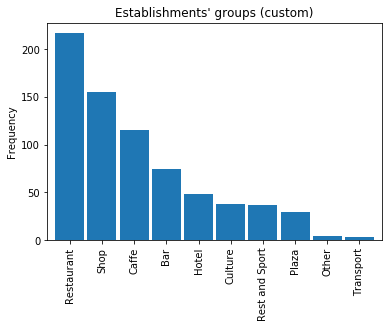

```python
establishment_occurencies = []
for venues in neighborhoods_venues_sorted.iloc[:, 2:].values:
    for establishments in venues:
        establishment_occurencies.append(establishments)


caffe = ['Café', 'Burger Joint', 'Sandwich Place', 'Bistro', 'Gastropub', 'Diner', 'Pizza Place', 'BBQ Joint', 'Salad Place', 'Tea Room',
         'Steakhouse', 'Food Truck', 'Buffet', 'Fried Chicken Joint', 'Creperie', 'Poke Place']
bar = ['Bar', 'Pub', 'Brasserie', 'Brewery', 'Beer Garden']
shop = ['Store', 'Beer Store', 'Flea Market', 'Health Food Store', 'Furniture / Home Store', 'Bookstore', 'Accessories Store', 'Department Store', 'Electronics Store', 'Shoe Store', 'Women\'s Store', 'Men\'s Store', 'Clothing Store', 'Grocery Store', 'Jewelry Store', 'Candy Store', 'Convenience Store', 'Boutique', 'Shop', 'Farmers Market', 'Supermarket', 'Organic Grocery', 'Grocery', 'Market', 'Bakery', 'Deli / Bodega']
plaza = ['Plaza', 'Pedestrian Plaza']
culture = ['Theater', 'Indie Movie Theater', 'Art Gallery', 'Street Art', 'Art Museum', 'History Museum', 'Science Museum', 'Concert Hall', 'Multiplex', 'Zoo Exhibit', 'Music Venue', 'Outdoor Sculpture']
rest_and_sport = ['Park', 'Boat or Ferry', 'Historic Site', 'Tennis Court', 'Stadium', 'Pool', 'Botanical Garden', 'Spa', 'Gym', 'Soccer Field',
                  'Lounge', 'Fountain', 'Forest', 'Lounge', 'Trail', 'Roof Deck', 'Gym Pool', 'Gym / Fitness Center']
transport = ['Tram Station', 'Bus Stop']

establishments_list = []

for i in establishment_occurencies:
    if 'restaurant' in i.lower():
        establishments_list.append('Restaurant')
    elif 'hotel' in i.lower():
        establishments_list.append('Hotel')
    elif str(caffe).lower().find(i.lower()) != -1:
        establishments_list.append('Caffe')
    elif (str(bar).lower().find(i.lower()) != -1) or ('Bar' in i):
        establishments_list.append('Bar')
    elif (str(shop).lower().find(i.lower()) != -1) or ('Shop' in i):
        establishments_list.append('Shop')
    elif str(plaza).lower().find(i.lower()) != -1:
        establishments_list.append('Plaza')
    elif str(culture).lower().find(i.lower()) != -1:
        establishments_list.append('Culture')
    elif str(rest_and_sport).lower().find(i.lower()) != -1:
        establishments_list.append('Rest and Sport')
    elif str(transport).lower().find(i.lower()) != -1:
        establishments_list.append('Transport')
    else:
        establishments_list.append('Other')

df_hist = pd.DataFrame({'establishments': establishments_list})
df_hist.reset_index(inplace=True)
df_hist.columns = ['count', 'establishments']
print('Total number of establishments:', df_hist.establishments.value_counts().sum())
print('\nPercent of establishments by each group:\n')
print(df_hist.establishments.value_counts() / df_hist.establishments.value_counts().sum() * 100)

ax = df_hist['establishments'].value_counts().plot(kind='bar', width=.9)
plt.title('Establishments\' groups (custom)')
plt.ylabel('Frequency')
plt.show()
```

## Cluster Neighborhoods

**Run k-means to cluster the neighborhood into 4 clusters.**

```python
# set number of clusters
kclusters = 4

paris_grouped_clustering = paris_grouped.drop('Neighborhood', 1)

# run k-means clustering
kmeans = KMeans(n_clusters=kclusters, random_state=0).fit(paris_grouped_clustering)

# check cluster labels generated for each row in the dataframe
kmeans.labels_[0:10]
```

```
array([1, 1, 2, 1, 1, 2, 0, 1, 1, 1])
```

Create a new dataframe that includes the cluster as well as the top 10 venues for each neighborhood.

```python
# add clustering labels
neighborhoods_venues_sorted.insert(0, 'Cluster Labels', kmeans.labels_)

paris_merged = neighborhoods

# merge paris_grouped with paris_data to add latitude/longitude for each neighborhood
paris_merged = paris_merged.join(neighborhoods_venues_sorted.set_index('Neighborhood'), on='Neighborhood')
paris_merged.dropna(inplace=True)

paris_merged.head()
```

|  | PostalCode | Borough | Arrondissement's Area | Arrondissement's Perimeter | Neighborhood | Neighborhood's Area | Latitude | Longitude | Cluster Labels | 1st Most Common Venue | 2nd Most Common Venue | 3rd Most Common Venue | 4th Most Common Venue | 5th Most Common Venue | 6th Most Common Venue | 7th Most Common Venue | 8th Most Common Venue | 9th Most Common Venue | 10th Most Common Venue |
| --- | --- | --- | --- | --- | --- | --- | --- | --- | --- | --- | --- | --- | --- | --- | --- | --- | --- | --- | --- |
| 0 | 75001 | Louvre | 1.824613e+06 | 6054.936862 | Saint-Germain-l'Auxerrois | 86.9 | 48.861408 | 2.333123 | 1 | Japanese Restaurant | Coffee Shop | French Restaurant | Historic Site | Art Museum | Plaza | Hotel | Café | Cosmetics Shop | Fountain |
| 1 | 75001 | Louvre | 1.824613e+06 | 6054.936862 | Halles | 41.2 | 48.862187 | 2.345243 | 2 | French Restaurant | Bakery | Ice Cream Shop | Spa | Thai Restaurant | Sandwich Place | Cocktail Bar | Pedestrian Plaza | Art Gallery | Restaurant |
| 2 | 75001 | Louvre | 1.824613e+06 | 6054.936862 | Palais-Royal | 27.4 | 48.864708 | 2.336496 | 1 | Japanese Restaurant | French Restaurant | Hotel | Café | Italian Restaurant | Coffee Shop | Plaza | Historic Site | Wine Bar | Bookstore |
| 3 | 75001 | Louvre | 1.824613e+06 | 6054.936862 | Place-Vendôme | 26.9 | 48.867780 | 2.330110 | 0 | Hotel | Japanese Restaurant | French Restaurant | Bookstore | Plaza | Tea Room | Dessert Shop | Bakery | Boutique | Chocolate Shop |
| 4 | 75002 | Bourse | 9.911537e+05 | 4554.104360 | Gaillon | 18.8 | 48.869020 | 2.334450 | 0 | Hotel | French Restaurant | Japanese Restaurant | Jewelry Store | Chocolate Shop | Wine Bar | Historic Site | Udon Restaurant | Plaza | Theater |

```python
paris_merged.tail() # check the last columns
```

|  | PostalCode | Borough | Arrondissement's Area | Arrondissement's Perimeter | Neighborhood | Neighborhood's Area | Latitude | Longitude | Cluster Labels | 1st Most Common Venue | 2nd Most Common Venue | 3rd Most Common Venue | 4th Most Common Venue | 5th Most Common Venue | 6th Most Common Venue | 7th Most Common Venue | 8th Most Common Venue | 9th Most Common Venue | 10th Most Common Venue |
| --- | --- | --- | --- | --- | --- | --- | --- | --- | --- | --- | --- | --- | --- | --- | --- | --- | --- | --- | --- |
| 75 | 75019 | Buttes-Chaumont | 6.792651e+06 | 11253.182479 | Combat | 129.5 | 48.883945 | 2.385625 | 2 | French Restaurant | Supermarket | Bar | Bakery | Lebanese Restaurant | Spa | Seafood Restaurant | Beer Garden | Pool | Chinese Restaurant |
| 76 | 75020 | Ménilmontant | 5.983446e+06 | 10704.940486 | Belleville | 80.7 | 48.870759 | 2.385372 | 1 | Bar | French Restaurant | Pizza Place | Bistro | African Restaurant | Cocktail Bar | Italian Restaurant | Burger Joint | Bookstore | Gastropub |
| 77 | 75020 | Ménilmontant | 5.983446e+06 | 10704.940486 | Saint-Fargeau | 148.7 | 48.871551 | 2.403990 | 1 | French Restaurant | Supermarket | Bakery | Indian Restaurant | Diner | Food Truck | Street Art | Café | Park | Market |
| 78 | 75020 | Ménilmontant | 5.983446e+06 | 10704.940486 | Père-Lachaise | 159.9 | 48.859890 | 2.389020 | 1 | Beer Bar | Bar | French Restaurant | Moroccan Restaurant | Restaurant | Organic Grocery | Theater | Cemetery | Gym Pool | Asian Restaurant |
| 79 | 75020 | Ménilmontant | 5.983446e+06 | 10704.940486 | Charonne | 209.1 | 48.854188 | 2.396330 | 2 | French Restaurant | Bar | Farmers Market | Italian Restaurant | Japanese Restaurant | Bookstore | Supermarket | Theater | Tech Startup | Hotel |

**Visualize the resulting clusters.**

```python
# create map
map_clusters = folium.Map(location=[latitude, longitude], zoom_start=12)

# set color scheme for the clusters
x = np.arange(kclusters)
ys = [i + x + (i*x)**2 for i in range(kclusters)]
colors_array = cm.rainbow(np.linspace(0, 1, len(ys)))
rainbow = [colors.rgb2hex(i) for i in colors_array]

# add markers to the map
markers_colors = []
for lat, lon, poi, cluster in zip(paris_merged['Latitude'], paris_merged['Longitude'], paris_merged['Neighborhood'], paris_merged['Cluster Labels']):
    cluster = int(cluster)
    label = folium.Popup(str(poi) + ' Cluster ' + str(cluster), parse_html=True)
    folium.CircleMarker(
        [lat, lon],
        radius=5,
        popup=label,
        color=rainbow[cluster-1],
        fill=True,
        fill_color=rainbow[cluster-1],
        fill_opacity=0.7).add_to(map_clusters)

map_clusters
```

Make this Notebook Trusted to load map: File -> Trust Notebook

[interactive chart not shown]

**Examine Clusters.**

#### Cluster 1

```python
paris_merged.loc[paris_merged['Cluster Labels'] == 0, paris_merged.columns[[1] + list(range(5, paris_merged.shape[1]))]]
```

|  | Borough | Neighborhood's Area | Latitude | Longitude | Cluster Labels | 1st Most Common Venue | 2nd Most Common Venue | 3rd Most Common Venue | 4th Most Common Venue | 5th Most Common Venue | 6th Most Common Venue | 7th Most Common Venue | 8th Most Common Venue | 9th Most Common Venue | 10th Most Common Venue |
| --- | --- | --- | --- | --- | --- | --- | --- | --- | --- | --- | --- | --- | --- | --- | --- |
| 3 | Louvre | 26.9 | 48.867780 | 2.330110 | 0 | Hotel | Japanese Restaurant | French Restaurant | Bookstore | Plaza | Tea Room | Dessert Shop | Bakery | Boutique | Chocolate Shop |
| 4 | Bourse | 18.8 | 48.869020 | 2.334450 | 0 | Hotel | French Restaurant | Japanese Restaurant | Jewelry Store | Chocolate Shop | Wine Bar | Historic Site | Udon Restaurant | Plaza | Theater |
| 17 | Panthéon | 79.8 | 48.842448 | 2.357202 | 0 | French Restaurant | Science Museum | Hotel | Garden | Zoo Exhibit | Museum | Botanical Garden | Italian Restaurant | Tea Room | Plaza |
| 23 | Luxembourg | 28.2 | 48.854829 | 2.333614 | 0 | French Restaurant | Hotel | Italian Restaurant | Wine Bar | Plaza | Café | Sandwich Place | Seafood Restaurant | Japanese Restaurant | Clothing Store |
| 24 | Palais-Bourbon | 82.7 | 48.855315 | 2.325613 | 0 | French Restaurant | Hotel | Café | Italian Restaurant | Bistro | Art Gallery | Coffee Shop | Hotel Bar | Tailor Shop | Furniture / Home Store |
| 26 | Palais-Bourbon | 80.8 | 48.850436 | 2.311343 | 0 | Hotel | French Restaurant | Plaza | Café | Asian Restaurant | Dessert Shop | Concert Hall | Diner | Pastry Shop | Farmers Market |
| 28 | Élysée | 114.1 | 48.869060 | 2.309930 | 0 | French Restaurant | Hotel | Garden | Plaza | Art Gallery | Jewelry Store | Cosmetics Shop | Spa | Clothing Store | Boutique |
| 29 | Élysée | 79.6 | 48.876818 | 2.299611 | 0 | French Restaurant | Hotel | Italian Restaurant | Bakery | Jewelry Store | Asian Restaurant | Bistro | Plaza | Tea Room | Sushi Restaurant |
| 30 | Élysée | 76.1 | 48.869300 | 2.323800 | 0 | Hotel | French Restaurant | Boutique | Women's Store | Dessert Shop | Men's Store | Plaza | Gourmet Shop | Bookstore | Shoe Store |
| 31 | Élysée | 118.3 | 48.880341 | 2.324489 | 0 | Hotel | Wine Bar | Sushi Restaurant | French Restaurant | Cosmetics Shop | Bookstore | Italian Restaurant | Japanese Restaurant | Steakhouse | Thai Restaurant |
| 33 | Opéra | 54.3 | 48.873750 | 2.332980 | 0 | French Restaurant | Hotel | Salad Place | Bistro | Department Store | Clothing Store | Tea Room | Gym / Fitness Center | Theater | Chinese Restaurant |
| 34 | Opéra | 41.7 | 48.874261 | 2.342063 | 0 | French Restaurant | Hotel | Italian Restaurant | Japanese Restaurant | Chinese Restaurant | Bakery | Wine Bar | Pizza Place | Gym / Fitness Center | Coffee Shop |
| 36 | Entrepôt | 92.7 | 48.878490 | 2.351760 | 0 | French Restaurant | Hotel | Japanese Restaurant | Seafood Restaurant | Indian Restaurant | Restaurant | Italian Restaurant | Korean Restaurant | Thai Restaurant | Wine Shop |
| 44 | Reuilly | 138.6 | 48.845090 | 2.406380 | 0 | Hotel | Japanese Restaurant | French Restaurant | Convenience Store | Pizza Place | Farmers Market | Supermarket | Bakery | Pharmacy | Sandwich Place |
| 48 | Gobelins | 118.2 | 48.835300 | 2.358300 | 0 | Hotel | French Restaurant | Italian Restaurant | Supermarket | Bar | Japanese Restaurant | Chinese Restaurant | Sushi Restaurant | Plaza | Multiplex |
| 51 | Gobelins | 69.2 | 48.833939 | 2.347926 | 0 | French Restaurant | Hotel | Italian Restaurant | Japanese Restaurant | Sushi Restaurant | Sandwich Place | Thai Restaurant | Bar | Bakery | Dessert Shop |
| 52 | Observatoire | 112.6 | 48.842800 | 2.323620 | 0 | French Restaurant | Hotel | Creperie | Japanese Restaurant | Italian Restaurant | Department Store | Auvergne Restaurant | Korean Restaurant | Café | Theater |
| 54 | Observatoire | 134.6 | 48.826420 | 2.325200 | 0 | Hotel | French Restaurant | Supermarket | Italian Restaurant | Japanese Restaurant | Café | Plaza | Bakery | Bistro | Sushi Restaurant |
| 57 | Vaugirard | 157.8 | 48.843290 | 2.313700 | 0 | French Restaurant | Hotel | Italian Restaurant | Korean Restaurant | Dessert Shop | Grocery Store | Bistro | Bar | Café | Museum |
| 58 | Vaugirard | 147.8 | 48.853310 | 2.328420 | 0 | French Restaurant | Hotel | Café | Plaza | Pastry Shop | Coffee Shop | American Restaurant | Bistro | Tailor Shop | Chocolate Shop |
| 62 | Passy | 141.4 | 48.878293 | 2.279673 | 0 | French Restaurant | Hotel | Italian Restaurant | Chinese Restaurant | Gym / Fitness Center | Hotel Bar | Plaza | American Restaurant | Pizza Place | Café |
| 63 | Passy | 142.4 | 48.867196 | 2.297359 | 0 | French Restaurant | Hotel | Art Museum | Italian Restaurant | Lebanese Restaurant | Hotel Bar | Accessories Store | Mediterranean Restaurant | Japanese Restaurant | Chinese Restaurant |
| 64 | Batignolles-Monceau | 146.6 | 48.878100 | 2.296790 | 0 | Hotel | French Restaurant | Italian Restaurant | Seafood Restaurant | Asian Restaurant | Breton Restaurant | Tea Room | Thai Restaurant | Bar | Japanese Restaurant |

#### Cluster 2

```python
paris_merged.loc[paris_merged['Cluster Labels'] == 1, paris_merged.columns[[1] + list(range(5, paris_merged.shape[1]))]]
```

|  | Borough | Neighborhood's Area | Latitude | Longitude | Cluster Labels | 1st Most Common Venue | 2nd Most Common Venue | 3rd Most Common Venue | 4th Most Common Venue | 5th Most Common Venue | 6th Most Common Venue | 7th Most Common Venue | 8th Most Common Venue | 9th Most Common Venue | 10th Most Common Venue |
| --- | --- | --- | --- | --- | --- | --- | --- | --- | --- | --- | --- | --- | --- | --- | --- |
| 0 | Louvre | 86.9 | 48.861408 | 2.333123 | 1 | Japanese Restaurant | Coffee Shop | French Restaurant | Historic Site | Art Museum | Plaza | Hotel | Café | Cosmetics Shop | Fountain |
| 2 | Louvre | 27.4 | 48.864708 | 2.336496 | 1 | Japanese Restaurant | French Restaurant | Hotel | Café | Italian Restaurant | Coffee Shop | Plaza | Historic Site | Wine Bar | Bookstore |
| 5 | Bourse | 24.4 | 48.871100 | 2.341280 | 1 | Hotel | French Restaurant | Pizza Place | Japanese Restaurant | Italian Restaurant | Gym / Fitness Center | Cocktail Bar | Gourmet Shop | Mexican Restaurant | Indie Movie Theater |
| 6 | Bourse | 27.8 | 48.866816 | 2.342632 | 1 | French Restaurant | Italian Restaurant | Wine Bar | Bistro | Clothing Store | Cheese Shop | Japanese Restaurant | Cocktail Bar | Bakery | Salad Place |
| 7 | Bourse | 28.2 | 48.869320 | 2.349510 | 1 | Hotel | Cocktail Bar | Wine Bar | Bakery | Bar | French Restaurant | Burger Joint | Italian Restaurant | Indie Movie Theater | Cheese Shop |
| 8 | Temple | 31.8 | 48.817694 | 2.334053 | 1 | Diner | Kebab Restaurant | Theater | Middle Eastern Restaurant | Brasserie | Pizza Place | BBQ Joint | Park | Japanese Restaurant | Italian Restaurant |
| 9 | Temple | 27.2 | 48.862940 | 2.361240 | 1 | Japanese Restaurant | Italian Restaurant | Coffee Shop | Art Gallery | Bistro | Wine Bar | Vietnamese Restaurant | Sandwich Place | French Restaurant | Burger Joint |
| 10 | Temple | 36.8 | 48.863570 | 2.360890 | 1 | French Restaurant | Japanese Restaurant | Cocktail Bar | Art Gallery | Italian Restaurant | Wine Bar | Bakery | Burger Joint | Sandwich Place | Bistro |
| 11 | Temple | 21.3 | 48.860610 | 2.356056 | 1 | Ice Cream Shop | Burger Joint | Art Gallery | Bakery | Deli / Bodega | Bistro | Creperie | Men's Store | French Restaurant | Art Museum |
| 12 | Hôtel-de-Ville | 31.3 | 48.858533 | 2.351467 | 1 | French Restaurant | Ice Cream Shop | Art Gallery | Bakery | Hotel | Café | Plaza | Historic Site | Coffee Shop | Burger Joint |
| 13 | Hôtel-de-Ville | 42.2 | 48.855403 | 2.358123 | 1 | French Restaurant | Clothing Store | Ice Cream Shop | Hotel | Thai Restaurant | Wine Bar | Italian Restaurant | Gourmet Shop | Plaza | Bakery |
| 15 | Hôtel-de-Ville | 37.9 | 48.853130 | 2.348860 | 1 | French Restaurant | Plaza | Bookstore | Bar | Mexican Restaurant | Bakery | Japanese Restaurant | Italian Restaurant | Ice Cream Shop | Flower Shop |
| 18 | Panthéon | 70.4 | 48.841862 | 2.344037 | 1 | French Restaurant | Bar | Hotel | Creperie | Science Museum | Bakery | Asian Restaurant | Poke Place | Chinese Restaurant | Chocolate Shop |
| 19 | Panthéon | 43.3 | 48.849558 | 2.345876 | 1 | French Restaurant | Hotel | Plaza | Bookstore | Indie Movie Theater | Coffee Shop | Bar | Mexican Restaurant | Bakery | Ice Cream Shop |
| 20 | Luxembourg | 29.3 | 48.854185 | 2.340354 | 1 | French Restaurant | Hotel | Plaza | Cocktail Bar | Creperie | Bistro | Seafood Restaurant | Historic Site | Wine Bar | Bookstore |
| 21 | Luxembourg | 71.6 | 48.848315 | 2.336586 | 1 | Hotel | Café | Bistro | French Restaurant | Bakery | Pastry Shop | Cocktail Bar | Plaza | Fountain | Clothing Store |
| 37 | Entrepôt | 47.2 | 48.869690 | 2.352660 | 1 | Bar | Cocktail Bar | French Restaurant | Hotel | Burger Joint | Wine Bar | Italian Restaurant | Coffee Shop | Restaurant | Farmers Market |
| 38 | Entrepôt | 60.9 | 48.869010 | 2.355640 | 1 | French Restaurant | Bar | Hotel | Italian Restaurant | Cocktail Bar | Coffee Shop | Vietnamese Restaurant | Bakery | Restaurant | Burger Joint |
| 39 | Entrepôt | 88.4 | 48.873030 | 2.369970 | 1 | French Restaurant | Italian Restaurant | Coffee Shop | Bar | Bistro | Chinese Restaurant | Restaurant | Tapas Restaurant | Middle Eastern Restaurant | Pizza Place |
| 40 | Popincourt | 72.6 | 48.864715 | 2.371208 | 1 | French Restaurant | Bar | Restaurant | Bakery | Japanese Restaurant | Bistro | Hotel | Italian Restaurant | Clothing Store | Wine Bar |
| 41 | Popincourt | 83.8 | 48.861662 | 2.376290 | 1 | French Restaurant | Restaurant | Bar | Bakery | Café | Bistro | Hotel | Wine Bar | Coffee Shop | Mexican Restaurant |
| 42 | Popincourt | 117.2 | 48.856947 | 2.378354 | 1 | French Restaurant | Bar | Italian Restaurant | Café | Bistro | Wine Bar | Cocktail Bar | Pastry Shop | Sandwich Place | Bookstore |
| 43 | Popincourt | 93.0 | 48.852670 | 2.381060 | 1 | French Restaurant | Bar | Bistro | Wine Bar | Cocktail Bar | Record Shop | Vietnamese Restaurant | Italian Restaurant | Bookstore | Pizza Place |
| 45 | Reuilly | 186.3 | 48.844420 | 2.402270 | 1 | Hotel | Pizza Place | Convenience Store | Farmers Market | Japanese Restaurant | Supermarket | Electronics Store | Thai Restaurant | Gastropub | Chinese Restaurant |
| 46 | Reuilly | 190.3 | 48.833591 | 2.386031 | 1 | Hotel | Bus Stop | Plaza | Museum | Bakery | French Restaurant | Japanese Restaurant | Italian Restaurant | Candy Store | Shopping Plaza |
| 47 | Reuilly | 123.6 | 48.851370 | 2.372210 | 1 | French Restaurant | Cocktail Bar | Bar | Bistro | Bookstore | Italian Restaurant | Café | Pub | Bakery | Pizza Place |
| 49 | Gobelins | 304.4 | 48.835537 | 2.375975 | 1 | Beer Garden | French Restaurant | Nightclub | Hotel | Italian Restaurant | Lounge | Bar | Bakery | Food Truck | Music Venue |
| 50 | Gobelins | 223.2 | 48.822630 | 2.358390 | 1 | Vietnamese Restaurant | Asian Restaurant | Chinese Restaurant | Thai Restaurant | Cantonese Restaurant | Diner | Juice Bar | Cambodian Restaurant | French Restaurant | Fast Food Restaurant |
| 53 | Observatoire | 135.7 | 48.824410 | 2.337780 | 1 | Bus Stop | Italian Restaurant | Japanese Restaurant | Indian Restaurant | Lebanese Restaurant | Diner | Plaza | Peruvian Restaurant | Chinese Restaurant | Park |
| 55 | Observatoire | 178.5 | 48.844550 | 2.389940 | 1 | French Restaurant | Supermarket | Bakery | Bar | Bistro | Italian Restaurant | Hotel | Chinese Restaurant | Sandwich Place | Vietnamese Restaurant |
| 59 | Vaugirard | 260.9 | 48.843870 | 2.286130 | 1 | French Restaurant | Hotel | Korean Restaurant | Persian Restaurant | Bakery | Restaurant | Coffee Shop | Lebanese Restaurant | Thai Restaurant | Japanese Restaurant |
| 60 | Passy | 303.0 | 48.845444 | 2.254189 | 1 | Tennis Court | French Restaurant | Plaza | Sporting Goods Shop | Brewery | Stadium | Pool | Roof Deck | Museum | Shopping Plaza |
| 67 | Batignolles-Monceau | 137.8 | 48.896496 | 2.324302 | 1 | Supermarket | French Restaurant | Japanese Restaurant | Hotel | Bus Stop | Pizza Place | Bar | Bakery | Pool | Gym |
| 70 | Buttes-Montmartre | 109.0 | 48.885010 | 2.354130 | 1 | Indian Restaurant | Supermarket | Bookstore | Plaza | Theater | Bar | Bakery | Health Food Store | French Restaurant | Bistro |
| 71 | Buttes-Montmartre | 134.8 | 48.884362 | 2.357151 | 1 | Indian Restaurant | Hotel | French Restaurant | Bakery | Supermarket | Grocery Store | Theater | Shopping Mall | Beer Bar | Restaurant |
| 73 | Buttes-Chaumont | 237.7 | 48.897546 | 2.381922 | 1 | Hotel | French Restaurant | Café | Chinese Restaurant | Tram Station | Asian Restaurant | Japanese Restaurant | Science Museum | Forest | Buffet |
| 74 | Buttes-Chaumont | 183.6 | 48.876200 | 2.393620 | 1 | Bar | Bakery | French Restaurant | Café | Restaurant | Japanese Restaurant | Gourmet Shop | Doner Restaurant | Theater | Beer Store |
| 76 | Ménilmontant | 80.7 | 48.870759 | 2.385372 | 1 | Bar | French Restaurant | Pizza Place | Bistro | African Restaurant | Cocktail Bar | Italian Restaurant | Burger Joint | Bookstore | Gastropub |
| 77 | Ménilmontant | 148.7 | 48.871551 | 2.403990 | 1 | French Restaurant | Supermarket | Bakery | Indian Restaurant | Diner | Food Truck | Street Art | Café | Park | Market |
| 78 | Ménilmontant | 159.9 | 48.859890 | 2.389020 | 1 | Beer Bar | Bar | French Restaurant | Moroccan Restaurant | Restaurant | Organic Grocery | Theater | Cemetery | Gym Pool | Asian Restaurant |

#### Cluster 3

```python
paris_merged.loc[paris_merged['Cluster Labels'] == 2, paris_merged.columns[[1] + list(range(5, paris_merged.shape[1]))]]
```

|  | Borough | Neighborhood's Area | Latitude | Longitude | Cluster Labels | 1st Most Common Venue | 2nd Most Common Venue | 3rd Most Common Venue | 4th Most Common Venue | 5th Most Common Venue | 6th Most Common Venue | 7th Most Common Venue | 8th Most Common Venue | 9th Most Common Venue | 10th Most Common Venue |
| --- | --- | --- | --- | --- | --- | --- | --- | --- | --- | --- | --- | --- | --- | --- | --- |
| 1 | Louvre | 41.2 | 48.862187 | 2.345243 | 2 | French Restaurant | Bakery | Ice Cream Shop | Spa | Thai Restaurant | Sandwich Place | Cocktail Bar | Pedestrian Plaza | Art Gallery | Restaurant |
| 14 | Hôtel-de-Ville | 48.7 | 48.851864 | 2.364707 | 2 | French Restaurant | Hotel | Plaza | Park | Gastropub | Italian Restaurant | Tapas Restaurant | Pedestrian Plaza | Vegetarian / Vegan Restaurant | Boat or Ferry |
| 16 | Panthéon | 60.4 | 48.847723 | 2.353412 | 2 | French Restaurant | Bar | Italian Restaurant | Hotel | Pub | Museum | Café | Bakery | Coffee Shop | Japanese Restaurant |
| 22 | Luxembourg | 86.1 | 48.842822 | 2.332133 | 2 | French Restaurant | Creperie | Hotel | Café | New American Restaurant | Tennis Court | Outdoor Sculpture | Juice Bar | Southwestern French Restaurant | Cocktail Bar |
| 25 | Palais-Bourbon | 107.4 | 48.858253 | 2.315687 | 2 | French Restaurant | Hotel | Plaza | Café | History Museum | Historic Site | Park | Bistro | Italian Restaurant | Art Museum |
| 27 | Palais-Bourbon | 138.2 | 48.858413 | 2.300991 | 2 | French Restaurant | Italian Restaurant | Hotel | Café | Ice Cream Shop | Coffee Shop | Bistro | Cheese Shop | Chinese Restaurant | Garden |
| 32 | Opéra | 71.7 | 48.879270 | 2.348840 | 2 | French Restaurant | Hotel | Italian Restaurant | Restaurant | Japanese Restaurant | Pizza Place | Bar | Korean Restaurant | Bistro | Vegetarian / Vegan Restaurant |
| 35 | Opéra | 50.1 | 48.882824 | 2.344555 | 2 | French Restaurant | Hotel | Bar | Coffee Shop | Bakery | Pizza Place | Italian Restaurant | Park | Asian Restaurant | Restaurant |
| 56 | Vaugirard | 283.1 | 48.841179 | 2.297599 | 2 | French Restaurant | Italian Restaurant | Bistro | Hotel | Bakery | Coffee Shop | Lebanese Restaurant | Bar | Indian Restaurant | Japanese Restaurant |
| 61 | Passy | 203.7 | 48.858340 | 2.270916 | 2 | French Restaurant | Bakery | Italian Restaurant | Garden | Supermarket | Hotel | Thai Restaurant | Tea Room | Gourmet Shop | Sushi Restaurant |
| 65 | Batignolles-Monceau | 138.4 | 48.883091 | 2.299712 | 2 | French Restaurant | Hotel | Bakery | Bistro | Italian Restaurant | Bar | Salad Place | Sandwich Place | Chinese Restaurant | Seafood Restaurant |
| 66 | Batignolles-Monceau | 144.2 | 48.889600 | 2.318920 | 2 | French Restaurant | Bar | Restaurant | Italian Restaurant | Pizza Place | Bistro | Turkish Restaurant | Park | Wine Bar | Ethiopian Restaurant |
| 68 | Buttes-Montmartre | 190.6 | 48.890303 | 2.330582 | 2 | French Restaurant | Bar | Hotel | Bakery | Italian Restaurant | Japanese Restaurant | Restaurant | Wine Bar | Hotel Bar | Bistro |
| 72 | Buttes-Chaumont | 128.6 | 48.877085 | 2.387862 | 2 | French Restaurant | Bar | Café | Restaurant | Bakery | Plaza | Hotel | Italian Restaurant | Bistro | Beer Garden |
| 75 | Buttes-Chaumont | 129.5 | 48.883945 | 2.385625 | 2 | French Restaurant | Supermarket | Bar | Bakery | Lebanese Restaurant | Spa | Seafood Restaurant | Beer Garden | Pool | Chinese Restaurant |
| 79 | Ménilmontant | 209.1 | 48.854188 | 2.396330 | 2 | French Restaurant | Bar | Farmers Market | Italian Restaurant | Japanese Restaurant | Bookstore | Supermarket | Theater | Tech Startup | Hotel |

#### Cluster 4

```python
paris_merged.loc[paris_merged['Cluster Labels'] == 3, paris_merged.columns[[1] + list(range(5, paris_merged.shape[1]))]]
```

|  | Borough | Neighborhood's Area | Latitude | Longitude | Cluster Labels | 1st Most Common Venue | 2nd Most Common Venue | 3rd Most Common Venue | 4th Most Common Venue | 5th Most Common Venue | 6th Most Common Venue | 7th Most Common Venue | 8th Most Common Venue | 9th Most Common Venue | 10th Most Common Venue |
| --- | --- | --- | --- | --- | --- | --- | --- | --- | --- | --- | --- | --- | --- | --- | --- |
| 69 | Buttes-Montmartre | 165.3 | 48.900988 | 2.347675 | 3 | Flea Market | Fast Food Restaurant | Fried Chicken Joint | Café | Bistro | Gym | Trail | Soccer Field | Beer Garden | Hotel |

```python
len(paris_merged.loc[paris_merged['Cluster Labels'] == 0, paris_merged.columns[[1] + list(range(5, paris_merged.shape[1]))]]), len(paris_merged.loc[paris_merged['Cluster Labels'] == 1, paris_merged.columns[[1] + list(range(5, paris_merged.shape[1]))]]), len(paris_merged.loc[paris_merged['Cluster Labels'] == 2, paris_merged.columns[[1] + list(range(5, paris_merged.shape[1]))]])
```

```
(23, 40, 16)
```

### Results

After conducting K-Means algorithm, the data was clustered into 4 groups / clusters.

**1st cluster** consists of **23 neighborhoods** with hotels and french restaurants as their 1st Most Common Venue (marked with red color on the map above). This establishments are located on the western part of Paris.

**2nd cluster** consists of **40 neighborhoods** with restaurants, bars and hotels as their 1st Most Common Venue (marked with violet / purple color on the map above). This establishments are located on the central, eastern, and southern part of Paris.

**3rd cluster** consists of **16 neighborhoods** with only french restaurants as their 1st Most Common Venue, bars and hotels as their 2nd Most Common Venue (marked with blue color on the map above). This establishments are evenly distributed throughout the city.

**4th cluster** include the **only Flea Market** in the data (marked with yellow color on the map above). It is located on the north of Paris.

### Discussion and Conclusion

In future research it would be additional help to use population data of each neighborhood in Paris. Since the most preferable place to open a restaurant is that where the number of competitors is the lowest. For our data it's western part of Paris up to public park Bois de Boulogne. However, it's not possible to conclude decisively about the exact place.

The best way to determine the exact place for opening a restaurant in western part of Paris is to use additional data, for example, anonymized data of mobile operators. These data will show a more detailed picture of potential visitors to the new restaurant